# Project: Identify Customer Segments

In this project, you will apply unsupervised learning techniques to identify segments of the population that form the core customer base for a mail-order sales company in Germany. These segments can then be used to direct marketing campaigns towards audiences that will have the highest expected rate of returns. The data that you will use has been provided by our partners at Bertelsmann Arvato Analytics, and represents a real-life data science task.

This notebook will help you complete this task by providing a framework within which you will perform your analysis steps. In each step of the project, you will see some text describing the subtask that you will perform, followed by one or more code cells for you to complete your work. **Feel free to add additional code and markdown cells as you go along so that you can explore everything in precise chunks.** The code cells provided in the base template will outline only the major tasks, and will usually not be enough to cover all of the minor tasks that comprise it.

It should be noted that while there will be precise guidelines on how you should handle certain tasks in the project, there will also be places where an exact specification is not provided. **There will be times in the project where you will need to make and justify your own decisions on how to treat the data.** These are places where there may not be only one way to handle the data. In real-life tasks, there may be many valid ways to approach an analysis task. One of the most important things you can do is clearly document your approach so that other scientists can understand the decisions you've made.

At the end of most sections, there will be a Markdown cell labeled **Discussion**. In these cells, you will report your findings for the completed section, as well as document the decisions that you made in your approach to each subtask. **Your project will be evaluated not just on the code used to complete the tasks outlined, but also your communication about your observations and conclusions at each stage.**

```python
# import libraries here; add more as necessary
import ast
import numpy as np
import pandas as pd
import matplotlib.pyplot as plt
import seaborn as sns
from collections import Counter
from sklearn.decomposition import PCA
from sklearn.preprocessing import Imputer
from sklearn.preprocessing import StandardScaler
from sklearn.cluster import KMeans

# magic word for producing visualizations in notebook
%matplotlib inline
```

### Step 0: Load the Data

Each row of the demographics files represents a single person, but also includes information outside of individuals, including information about their household, building, and neighborhood. You will use this information to cluster the general population into groups with similar demographic properties. Then, you will see how the people in the customers dataset fit into those created clusters. The hope here is that certain clusters are over-represented in the customers data, as compared to the general population; those over-represented clusters will be assumed to be part of the core userbase. This information can then be used for further applications, such as targeting for a marketing campaign.

To start off with, load in the demographics data for the general population into a pandas DataFrame, and do the same for the feature attributes summary. Note for all of the `.csv` data files in this project: they're semicolon (`;`) delimited, so you'll need an additional argument in your [`read_csv()`](https://pandas.pydata.org/pandas-docs/stable/generated/pandas.read_csv.html) call to read in the data properly. Also, considering the size of the main dataset, it may take some time for it to load completely.

Once the dataset is loaded, it's recommended that you take a little bit of time just browsing the general structure of the dataset and feature summary file. You'll be getting deep into the innards of the cleaning in the first major step of the project, so gaining some general familiarity can help you get your bearings.

```python
# Load in the general demographics data.
azdias = pd.read_csv('Udacity_AZDIAS_Subset.csv', sep=';')

# Load in the feature summary file.
feat_info = pd.read_csv('AZDIAS_Feature_Summary.csv', sep=';')
```

```python
# Check the structure of the data after it's loaded (e.g. print the number of
# rows and columns, print the first few rows).
print("General population dataset shape : ", azdias.shape)
azdias.describe()
```

```
General population dataset shape :  (891221, 85)
```

|  | AGER_TYP | ALTERSKATEGORIE_GROB | ANREDE_KZ | CJT_GESAMTTYP | FINANZ_MINIMALIST | FINANZ_SPARER | FINANZ_VORSORGER | FINANZ_ANLEGER | FINANZ_UNAUFFAELLIGER | FINANZ_HAUSBAUER | ... | PLZ8_ANTG1 | PLZ8_ANTG2 | PLZ8_ANTG3 | PLZ8_ANTG4 | PLZ8_BAUMAX | PLZ8_HHZ | PLZ8_GBZ | ARBEIT | ORTSGR_KLS9 | RELAT_AB |
| --- | --- | --- | --- | --- | --- | --- | --- | --- | --- | --- | --- | --- | --- | --- | --- | --- | --- | --- | --- | --- | --- |
| count | 891221.000000 | 891221.000000 | 891221.000000 | 886367.000000 | 891221.000000 | 891221.000000 | 891221.000000 | 891221.000000 | 891221.000000 | 891221.000000 | ... | 774706.000000 | 774706.000000 | 774706.000000 | 774706.000000 | 774706.000000 | 774706.000000 | 774706.000000 | 794005.000000 | 794005.000000 | 794005.00000 |
| mean | -0.358435 | 2.777398 | 1.522098 | 3.632838 | 3.074528 | 2.821039 | 3.401106 | 3.033328 | 2.874167 | 3.075121 | ... | 2.253330 | 2.801858 | 1.595426 | 0.699166 | 1.943913 | 3.612821 | 3.381087 | 3.167854 | 5.293002 | 3.07222 |
| std | 1.198724 | 1.068775 | 0.499512 | 1.595021 | 1.321055 | 1.464749 | 1.322134 | 1.529603 | 1.486731 | 1.353248 | ... | 0.972008 | 0.920309 | 0.986736 | 0.727137 | 1.459654 | 0.973967 | 1.111598 | 1.002376 | 2.303739 | 1.36298 |
| min | -1.000000 | 1.000000 | 1.000000 | 1.000000 | 1.000000 | 1.000000 | 1.000000 | 1.000000 | 1.000000 | 1.000000 | ... | 0.000000 | 0.000000 | 0.000000 | 0.000000 | 1.000000 | 1.000000 | 1.000000 | 1.000000 | 0.000000 | 1.00000 |
| 25% | -1.000000 | 2.000000 | 1.000000 | 2.000000 | 2.000000 | 1.000000 | 3.000000 | 2.000000 | 2.000000 | 2.000000 | ... | 1.000000 | 2.000000 | 1.000000 | 0.000000 | 1.000000 | 3.000000 | 3.000000 | 3.000000 | 4.000000 | 2.00000 |
| 50% | -1.000000 | 3.000000 | 2.000000 | 4.000000 | 3.000000 | 3.000000 | 3.000000 | 3.000000 | 3.000000 | 3.000000 | ... | 2.000000 | 3.000000 | 2.000000 | 1.000000 | 1.000000 | 4.000000 | 3.000000 | 3.000000 | 5.000000 | 3.00000 |
| 75% | -1.000000 | 4.000000 | 2.000000 | 5.000000 | 4.000000 | 4.000000 | 5.000000 | 5.000000 | 4.000000 | 4.000000 | ... | 3.000000 | 3.000000 | 2.000000 | 1.000000 | 3.000000 | 4.000000 | 4.000000 | 4.000000 | 7.000000 | 4.00000 |
| max | 3.000000 | 9.000000 | 2.000000 | 6.000000 | 5.000000 | 5.000000 | 5.000000 | 5.000000 | 5.000000 | 5.000000 | ... | 4.000000 | 4.000000 | 3.000000 | 2.000000 | 5.000000 | 5.000000 | 5.000000 | 9.000000 | 9.000000 | 9.00000 |

8 rows × 81 columns

```python
n_values = len(azdias) * len(azdias.columns)
print("The total number of values in the DataFrame is : ", n_values)
azdias.head()
```

```
The total number of values in the DataFrame is :  75753785
```

|  | AGER_TYP | ALTERSKATEGORIE_GROB | ANREDE_KZ | CJT_GESAMTTYP | FINANZ_MINIMALIST | FINANZ_SPARER | FINANZ_VORSORGER | FINANZ_ANLEGER | FINANZ_UNAUFFAELLIGER | FINANZ_HAUSBAUER | ... | PLZ8_ANTG1 | PLZ8_ANTG2 | PLZ8_ANTG3 | PLZ8_ANTG4 | PLZ8_BAUMAX | PLZ8_HHZ | PLZ8_GBZ | ARBEIT | ORTSGR_KLS9 | RELAT_AB |
| --- | --- | --- | --- | --- | --- | --- | --- | --- | --- | --- | --- | --- | --- | --- | --- | --- | --- | --- | --- | --- | --- |
| 0 | -1 | 2 | 1 | 2.0 | 3 | 4 | 3 | 5 | 5 | 3 | ... | NaN | NaN | NaN | NaN | NaN | NaN | NaN | NaN | NaN | NaN |
| 1 | -1 | 1 | 2 | 5.0 | 1 | 5 | 2 | 5 | 4 | 5 | ... | 2.0 | 3.0 | 2.0 | 1.0 | 1.0 | 5.0 | 4.0 | 3.0 | 5.0 | 4.0 |
| 2 | -1 | 3 | 2 | 3.0 | 1 | 4 | 1 | 2 | 3 | 5 | ... | 3.0 | 3.0 | 1.0 | 0.0 | 1.0 | 4.0 | 4.0 | 3.0 | 5.0 | 2.0 |
| 3 | 2 | 4 | 2 | 2.0 | 4 | 2 | 5 | 2 | 1 | 2 | ... | 2.0 | 2.0 | 2.0 | 0.0 | 1.0 | 3.0 | 4.0 | 2.0 | 3.0 | 3.0 |
| 4 | -1 | 3 | 1 | 5.0 | 4 | 3 | 4 | 1 | 3 | 2 | ... | 2.0 | 4.0 | 2.0 | 1.0 | 2.0 | 3.0 | 3.0 | 4.0 | 6.0 | 5.0 |

5 rows × 85 columns

```python
print("Feature dataset shape : ", feat_info.shape)
feat_info.head()
```

```
Feature dataset shape :  (85, 4)
```

|  | attribute | information_level | type | missing_or_unknown |
| --- | --- | --- | --- | --- |
| 0 | AGER_TYP | person | categorical | [-1,0] |
| 1 | ALTERSKATEGORIE_GROB | person | ordinal | [-1,0,9] |
| 2 | ANREDE_KZ | person | categorical | [-1,0] |
| 3 | CJT_GESAMTTYP | person | categorical | [0] |
| 4 | FINANZ_MINIMALIST | person | ordinal | [-1] |

> **Tip**: Add additional cells to keep everything in reasonably-sized chunks! Keyboard shortcut `esc --> a` (press escape to enter command mode, then press the 'A' key) adds a new cell before the active cell, and `esc --> b` adds a new cell after the active cell. If you need to convert an active cell to a markdown cell, use `esc --> m` and to convert to a code cell, use `esc --> y`.

## Step 1: Preprocessing

### Step 1.1: Assess Missing Data

The feature summary file contains a summary of properties for each demographics data column. You will use this file to help you make cleaning decisions during this stage of the project. First of all, you should assess the demographics data in terms of missing data. Pay attention to the following points as you perform your analysis, and take notes on what you observe. Make sure that you fill in the **Discussion** cell with your findings and decisions at the end of each step that has one!

#### Step 1.1.1: Convert Missing Value Codes to NaNs

The fourth column of the feature attributes summary (loaded in above as `feat_info`) documents the codes from the data dictionary that indicate missing or unknown data. While the file encodes this as a list (e.g. `[-1,0]`), this will get read in as a string object. You'll need to do a little bit of parsing to make use of it to identify and clean the data. Convert data that matches a 'missing' or 'unknown' value code into a numpy NaN value. You might want to see how much data takes on a 'missing' or 'unknown' code, and how much data is naturally missing, as a point of interest.

**As one more reminder, you are encouraged to add additional cells to break up your analysis into manageable chunks.**

```python
# Identify missing or unknown data values and convert them to NaNs.
missing_values = azdias.isnull().sum().sum()
print("The number of naturally missing values is : ", missing_values)
print("The percentage of naturally missing values is : {:.3f} %".format(missing_values / n_values * 100))
```

```
The number of naturally missing values is :  4896838
The percentage of naturally missing values is : 6.464 %
```

```python
def convert_encodings(encodings):
    """
    Convert the string representation of a list to a list with the correct value types
    """
    encodings_list = encodings[1:-1].split(',')
    return [val if val in ['X', 'XX', ''] else int(val) for val in encodings_list]


# Create a dictionary with the columns names associated with their list of missing values encodings
missing_encodings = {feat_info["attribute"][i]: convert_encodings(feat_info["missing_or_unknown"][i]) for i in range(len(feat_info))}
```

```python
missing_values = azdias.isin(missing_encodings)
print("The number of missing or unknown values in the original dataset is : {}".format(missing_values.sum().sum()))
print("The percentage of missing or unknown values in the original dataset is : {:.3f} %".format(missing_values.sum().sum() / n_values * 100))
```

```
The number of missing or unknown values in the original dataset is : 3477091
The percentage of missing or unknown values in the original dataset is : 4.590 %
```

```python
mask = azdias.isin(missing_encodings) == False
cleaned_data = azdias[mask]
```

```python
cleaned_data.head()
```

|  | AGER_TYP | ALTERSKATEGORIE_GROB | ANREDE_KZ | CJT_GESAMTTYP | FINANZ_MINIMALIST | FINANZ_SPARER | FINANZ_VORSORGER | FINANZ_ANLEGER | FINANZ_UNAUFFAELLIGER | FINANZ_HAUSBAUER | ... | PLZ8_ANTG1 | PLZ8_ANTG2 | PLZ8_ANTG3 | PLZ8_ANTG4 | PLZ8_BAUMAX | PLZ8_HHZ | PLZ8_GBZ | ARBEIT | ORTSGR_KLS9 | RELAT_AB |
| --- | --- | --- | --- | --- | --- | --- | --- | --- | --- | --- | --- | --- | --- | --- | --- | --- | --- | --- | --- | --- | --- |
| 0 | NaN | 2.0 | 1 | 2.0 | 3 | 4 | 3 | 5 | 5 | 3 | ... | NaN | NaN | NaN | NaN | NaN | NaN | NaN | NaN | NaN | NaN |
| 1 | NaN | 1.0 | 2 | 5.0 | 1 | 5 | 2 | 5 | 4 | 5 | ... | 2.0 | 3.0 | 2.0 | 1.0 | 1.0 | 5.0 | 4.0 | 3.0 | 5.0 | 4.0 |
| 2 | NaN | 3.0 | 2 | 3.0 | 1 | 4 | 1 | 2 | 3 | 5 | ... | 3.0 | 3.0 | 1.0 | 0.0 | 1.0 | 4.0 | 4.0 | 3.0 | 5.0 | 2.0 |
| 3 | 2.0 | 4.0 | 2 | 2.0 | 4 | 2 | 5 | 2 | 1 | 2 | ... | 2.0 | 2.0 | 2.0 | 0.0 | 1.0 | 3.0 | 4.0 | 2.0 | 3.0 | 3.0 |
| 4 | NaN | 3.0 | 1 | 5.0 | 4 | 3 | 4 | 1 | 3 | 2 | ... | 2.0 | 4.0 | 2.0 | 1.0 | 2.0 | 3.0 | 3.0 | 4.0 | 6.0 | 5.0 |

5 rows × 85 columns

```python
missing_values = cleaned_data.isnull().sum().sum()
print("After clean up, the number of NaN values is : ", missing_values)
print("After clean up, the percentage of NaN values is : {:.3f} %".format(missing_values / n_values * 100))
```

```
After clean up, the number of NaN values is :  8373929
After clean up, the percentage of NaN values is : 11.054 %
```

#### Step 1.1.2: Assess Missing Data in Each Column

How much missing data is present in each column? There are a few columns that are outliers in terms of the proportion of values that are missing. You will want to use matplotlib's [`hist()`](https://matplotlib.org/api/_as_gen/matplotlib.pyplot.hist.html) function to visualize the distribution of missing value counts to find these columns. Identify and document these columns. While some of these columns might have justifications for keeping or re-encoding the data, for this project you should just remove them from the dataframe. (Feel free to make remarks about these outlier columns in the discussion, however!)

For the remaining features, are there any patterns in which columns have, or share, missing data?

```python
# Perform an assessment of how much missing data there is in each column of the
# dataset.
missing_values_per_column = cleaned_data.apply(lambda col: sum(col.isnull().values), axis = 0)
n_columns_with_missing_values = sum(missing_values_per_column.apply(lambda col: col > 0))
column_with_max_value = missing_values_per_column.idxmax(axis=1)
max_value = missing_values_per_column[column_with_max_value]
third = int(len(cleaned_data) / 3)
columns_with_third_missing_values = missing_values_per_column.loc[lambda col: col > third]
n_columns = len(missing_values_per_column)
n_rows = len(cleaned_data)
```

```python
# Investigate patterns in the amount of missing data in each column.
print("There are {}/{} columns that have at least one missing value.".format(n_columns_with_missing_values, n_columns))
print("The column with the max number of missing values is {} and it has {} missing values out of {} total values."
      .format(column_with_max_value, max_value, n_rows))
print("There are {} columns having at least a third of their values missing and those colums are : {}"
      .format(len(columns_with_third_missing_values), list(columns_with_third_missing_values.keys())))
```

```
There are 61/85 columns that have at least one missing value.
The column with the max number of missing values is TITEL_KZ and it has 889061 missing values out of 891221 total values.
There are 6 columns having at least a third of their values missing and those colums are : ['AGER_TYP', 'GEBURTSJAHR', 'TITEL_KZ', 'ALTER_HH', 'KK_KUNDENTYP', 'KBA05_BAUMAX']
```

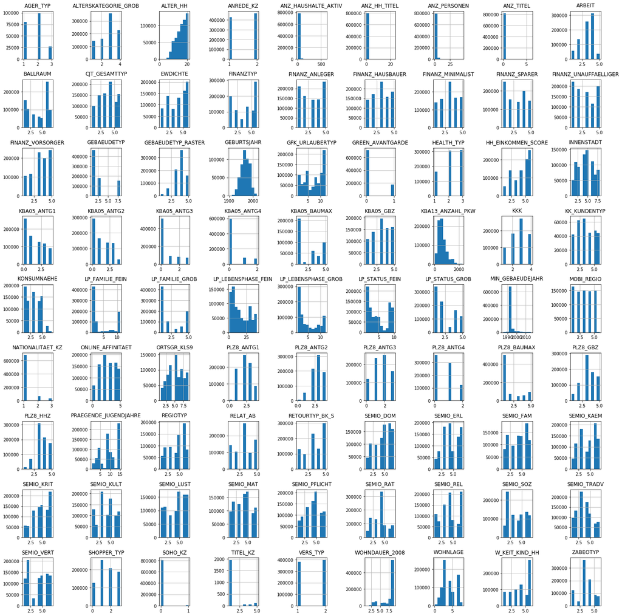

```python
cleaned_data.hist(bins=10, figsize=(20,20))
plt.tight_layout()
plt.show()
```

```python
# Columns that have their values represented majoritarly by a unique value
columns_with_unique_value = ['ANZ_TITEL', 'ANZ_HAUSHALTE_AKTIV', 'ANZ_HH_TITEL', 'ANZ_PERSONEN', 'SOHO_KZ']
```

```python
# Remove the outlier columns from the dataset. (You'll perform other data
# engineering tasks such as re-encoding and imputation later.)
cleaned_data = cleaned_data.drop(list(columns_with_third_missing_values.keys()), axis=1)
cleaned_data = cleaned_data.drop(columns_with_unique_value, axis=1)
cleaned_data.head()
```

|  | ALTERSKATEGORIE_GROB | ANREDE_KZ | CJT_GESAMTTYP | FINANZ_MINIMALIST | FINANZ_SPARER | FINANZ_VORSORGER | FINANZ_ANLEGER | FINANZ_UNAUFFAELLIGER | FINANZ_HAUSBAUER | FINANZTYP | ... | PLZ8_ANTG1 | PLZ8_ANTG2 | PLZ8_ANTG3 | PLZ8_ANTG4 | PLZ8_BAUMAX | PLZ8_HHZ | PLZ8_GBZ | ARBEIT | ORTSGR_KLS9 | RELAT_AB |
| --- | --- | --- | --- | --- | --- | --- | --- | --- | --- | --- | --- | --- | --- | --- | --- | --- | --- | --- | --- | --- | --- |
| 0 | 2.0 | 1 | 2.0 | 3 | 4 | 3 | 5 | 5 | 3 | 4 | ... | NaN | NaN | NaN | NaN | NaN | NaN | NaN | NaN | NaN | NaN |
| 1 | 1.0 | 2 | 5.0 | 1 | 5 | 2 | 5 | 4 | 5 | 1 | ... | 2.0 | 3.0 | 2.0 | 1.0 | 1.0 | 5.0 | 4.0 | 3.0 | 5.0 | 4.0 |
| 2 | 3.0 | 2 | 3.0 | 1 | 4 | 1 | 2 | 3 | 5 | 1 | ... | 3.0 | 3.0 | 1.0 | 0.0 | 1.0 | 4.0 | 4.0 | 3.0 | 5.0 | 2.0 |
| 3 | 4.0 | 2 | 2.0 | 4 | 2 | 5 | 2 | 1 | 2 | 6 | ... | 2.0 | 2.0 | 2.0 | 0.0 | 1.0 | 3.0 | 4.0 | 2.0 | 3.0 | 3.0 |
| 4 | 3.0 | 1 | 5.0 | 4 | 3 | 4 | 1 | 3 | 2 | 5 | ... | 2.0 | 4.0 | 2.0 | 1.0 | 2.0 | 3.0 | 3.0 | 4.0 | 6.0 | 5.0 |

5 rows × 74 columns

#### Step 1.1.3: Assess Missing Data in Each Row

Now, you'll perform a similar assessment for the rows of the dataset. How much data is missing in each row? As with the columns, you should see some groups of points that have a very different numbers of missing values. Divide the data into two subsets: one for data points that are above some threshold for missing values, and a second subset for points below that threshold.

In order to know what to do with the outlier rows, we should see if the distribution of data values on columns that are not missing data (or are missing very little data) are similar or different between the two groups. Select at least five of these columns and compare the distribution of values.

- You can use seaborn's [`countplot()`](https://seaborn.pydata.org/generated/seaborn.countplot.html) function to create a bar chart of code frequencies and matplotlib's [`subplot()`](https://matplotlib.org/api/_as_gen/matplotlib.pyplot.subplot.html) function to put bar charts for the two subplots side by side.
- To reduce repeated code, you might want to write a function that can perform this comparison, taking as one of its arguments a column to be compared.

Depending on what you observe in your comparison, this will have implications on how you approach your conclusions later in the analysis. If the distributions of non-missing features look similar between the data with many missing values and the data with few or no missing values, then we could argue that simply dropping those points from the analysis won't present a major issue. On the other hand, if the data with many missing values looks very different from the data with few or no missing values, then we should make a note on those data as special. We'll revisit these data later on. **Either way, you should continue your analysis for now using just the subset of the data with few or no missing values.**

```python
# How much data is missing in each row of the dataset?
missing_values_per_row = cleaned_data.apply(lambda x: sum(x.isnull().values), axis = 1)
n_rows_with_missing_values = sum(missing_values_per_row.apply(lambda row: row > 0))
n_rows = len(missing_values_per_row)
```

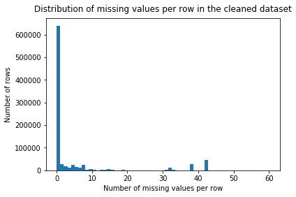

```python
mean_missing_values = np.mean(missing_values_per_row)
max_missing_values = np.max(missing_values_per_row)
plt.hist(cleaned_data.isnull().sum(axis = 1), bins = np.linspace(0, 60, 60))
plt.xlabel('Number of missing values per row')
plt.ylabel('Number of rows')
plt.title('Distribution of missing values per row in the cleaned dataset')
plt.show()
```

```python
print("There are {}/{} rows that have at least one missing value.".format(n_rows_with_missing_values, n_rows))
print("The average number of missing values per row is {:.2f} and the maximum number is {}".format(mean_missing_values, max_missing_values))
```

```
There are 266313/891221 rows that have at least one missing value.
The average number of missing values per row is 5.18 and the maximum number is 47
```

```python
# Write code to divide the data into two subsets based on the number of missing
# values in each row.
def split_data(data, threshold):
    missing_values_per_row = data.apply(lambda row: sum(row.isnull().values), axis=1)
    good_rows = missing_values_per_row.loc[lambda row: row <= threshold]
    good_data = data.loc[list(good_rows.keys())]
    outliers_data = data[data.index.isin(list(good_rows.keys())) == False]
    return good_data, outliers_data
```

```python
# Compare the distribution of values for at least five columns where there are
# no or few missing values, between the two subsets.
def compare_distributions(col, data, threshold):
    good_data, outliers = split_data(data, threshold)
    fig, axes = plt.subplots(1, 2)
    plt.tight_layout(w_pad=5.0)
    axes[0].set_title("Good data")
    sns.countplot(good_data[col], ax=axes[0])
    axes[1].set_title("Outliers")
    sns.countplot(outliers[col], ax=axes[1])
```

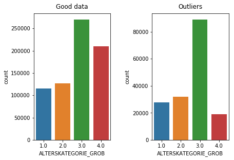

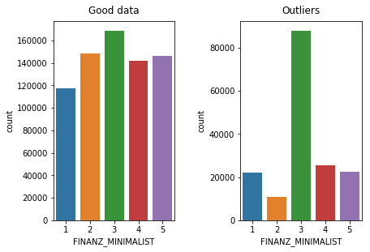

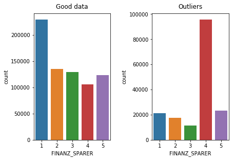

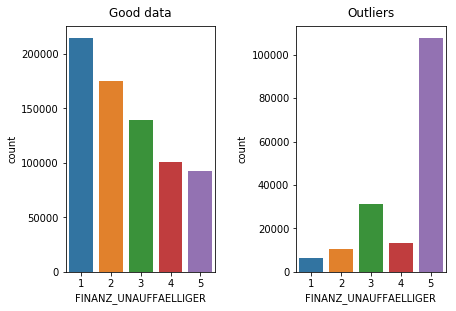

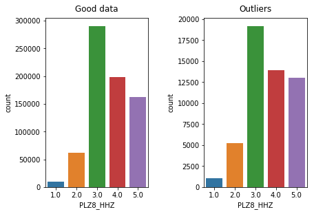

```python
threshold = 5
col_names = ['ALTERSKATEGORIE_GROB', 'FINANZ_MINIMALIST', 'FINANZ_SPARER', 'FINANZ_UNAUFFAELLIGER', 'PLZ8_HHZ']
for col in col_names:
    compare_distributions(col, cleaned_data, threshold)
```

```python
# Keep only the data that has few missing values. We use a threhold of 5 of missing values per row.
data, outliers = split_data(cleaned_data, 5)
data.head()
```

|  | ALTERSKATEGORIE_GROB | ANREDE_KZ | CJT_GESAMTTYP | FINANZ_MINIMALIST | FINANZ_SPARER | FINANZ_VORSORGER | FINANZ_ANLEGER | FINANZ_UNAUFFAELLIGER | FINANZ_HAUSBAUER | FINANZTYP | ... | PLZ8_ANTG1 | PLZ8_ANTG2 | PLZ8_ANTG3 | PLZ8_ANTG4 | PLZ8_BAUMAX | PLZ8_HHZ | PLZ8_GBZ | ARBEIT | ORTSGR_KLS9 | RELAT_AB |
| --- | --- | --- | --- | --- | --- | --- | --- | --- | --- | --- | --- | --- | --- | --- | --- | --- | --- | --- | --- | --- | --- |
| 1 | 1.0 | 2 | 5.0 | 1 | 5 | 2 | 5 | 4 | 5 | 1 | ... | 2.0 | 3.0 | 2.0 | 1.0 | 1.0 | 5.0 | 4.0 | 3.0 | 5.0 | 4.0 |
| 2 | 3.0 | 2 | 3.0 | 1 | 4 | 1 | 2 | 3 | 5 | 1 | ... | 3.0 | 3.0 | 1.0 | 0.0 | 1.0 | 4.0 | 4.0 | 3.0 | 5.0 | 2.0 |
| 4 | 3.0 | 1 | 5.0 | 4 | 3 | 4 | 1 | 3 | 2 | 5 | ... | 2.0 | 4.0 | 2.0 | 1.0 | 2.0 | 3.0 | 3.0 | 4.0 | 6.0 | 5.0 |
| 5 | 1.0 | 2 | 2.0 | 3 | 1 | 5 | 2 | 2 | 5 | 2 | ... | 2.0 | 3.0 | 1.0 | 1.0 | 1.0 | 5.0 | 5.0 | 2.0 | 3.0 | 3.0 |
| 6 | 2.0 | 2 | 5.0 | 1 | 5 | 1 | 5 | 4 | 3 | 4 | ... | 3.0 | 3.0 | 1.0 | 0.0 | 1.0 | 5.0 | 5.0 | 4.0 | 6.0 | 3.0 |

5 rows × 74 columns

```python
print(data.shape)
```

```
(722258, 74)
```

### Step 1.2: Select and Re-Encode Features

Checking for missing data isn't the only way in which you can prepare a dataset for analysis. Since the unsupervised learning techniques to be used will only work on data that is encoded numerically, you need to make a few encoding changes or additional assumptions to be able to make progress. In addition, while almost all of the values in the dataset are encoded using numbers, not all of them represent numeric values. Check the third column of the feature summary (`feat_info`) for a summary of types of measurement.

- For numeric and interval data, these features can be kept without changes.
- Most of the variables in the dataset are ordinal in nature. While ordinal values may technically be non-linear in spacing, make the simplifying assumption that the ordinal variables can be treated as being interval in nature (that is, kept without any changes).
- Special handling may be necessary for the remaining two variable types: categorical, and 'mixed'.

In the first two parts of this sub-step, you will perform an investigation of the categorical and mixed-type features and make a decision on each of them, whether you will keep, drop, or re-encode each. Then, in the last part, you will create a new data frame with only the selected and engineered columns.

Data wrangling is often the trickiest part of the data analysis process, and there's a lot of it to be done here. But stick with it: once you're done with this step, you'll be ready to get to the machine learning parts of the project!

```python
# How many features are there of each data type?
feat_info.groupby('type').count()['attribute']
```

```
type
categorical    21
interval        1
mixed           7
numeric         7
ordinal        49
Name: attribute, dtype: int64
```

#### Step 1.2.1: Re-Encode Categorical Features

For categorical data, you would ordinarily need to encode the levels as dummy variables. Depending on the number of categories, perform one of the following:

- For binary (two-level) categoricals that take numeric values, you can keep them without needing to do anything.
- There is one binary variable that takes on non-numeric values. For this one, you need to re-encode the values as numbers or create a dummy variable.
- For multi-level categoricals (three or more values), you can choose to encode the values using multiple dummy variables (e.g. via [OneHotEncoder](http://scikit-learn.org/stable/modules/generated/sklearn.preprocessing.OneHotEncoder.html)), or (to keep things straightforward) just drop them from the analysis. As always, document your choices in the Discussion section.

```python
# Assess categorical variables: which are binary, which are multi-level, and
# which one needs to be re-encoded?
columns_with_cat_values = list(feat_info.loc[feat_info['type']=='categorical']['attribute'])
cat_data = data.filter(items=columns_with_cat_values, axis=1)
cat_data.head()
```

|  | ANREDE_KZ | CJT_GESAMTTYP | FINANZTYP | GFK_URLAUBERTYP | GREEN_AVANTGARDE | LP_FAMILIE_FEIN | LP_FAMILIE_GROB | LP_STATUS_FEIN | LP_STATUS_GROB | NATIONALITAET_KZ | SHOPPER_TYP | VERS_TYP | ZABEOTYP | GEBAEUDETYP | OST_WEST_KZ | CAMEO_DEUG_2015 | CAMEO_DEU_2015 |
| --- | --- | --- | --- | --- | --- | --- | --- | --- | --- | --- | --- | --- | --- | --- | --- | --- | --- |
| 1 | 2 | 5.0 | 1 | 10.0 | 0 | 5.0 | 3.0 | 2.0 | 1.0 | 1.0 | 3.0 | 2.0 | 5 | 8.0 | W | 8 | 8A |
| 2 | 2 | 3.0 | 1 | 10.0 | 1 | 1.0 | 1.0 | 3.0 | 2.0 | 1.0 | 2.0 | 1.0 | 5 | 1.0 | W | 4 | 4C |
| 4 | 1 | 5.0 | 5 | 5.0 | 0 | 10.0 | 5.0 | 3.0 | 2.0 | 1.0 | 2.0 | 2.0 | 4 | 1.0 | W | 6 | 6B |
| 5 | 2 | 2.0 | 2 | 1.0 | 0 | 1.0 | 1.0 | 4.0 | 2.0 | 1.0 | 0.0 | 2.0 | 4 | 1.0 | W | 8 | 8C |
| 6 | 2 | 5.0 | 4 | 12.0 | 0 | 1.0 | 1.0 | 2.0 | 1.0 | 1.0 | 1.0 | 1.0 | 4 | 1.0 | W | 4 | 4A |

```python
# Compute the number of different categorical values per column
cat_number_of_values = cat_data.apply(lambda col: len(col.unique()))
cat_number_of_values
```

```
ANREDE_KZ            2
CJT_GESAMTTYP        6
FINANZTYP            6
GFK_URLAUBERTYP     12
GREEN_AVANTGARDE     2
LP_FAMILIE_FEIN     12
LP_FAMILIE_GROB      6
LP_STATUS_FEIN      10
LP_STATUS_GROB       5
NATIONALITAET_KZ     4
SHOPPER_TYP          5
VERS_TYP             3
ZABEOTYP             6
GEBAEUDETYP          7
OST_WEST_KZ          2
CAMEO_DEUG_2015     10
CAMEO_DEU_2015      45
dtype: int64
```

```python
# Perform data cleaning of categorical values
columns_to_drop = list(cat_number_of_values.loc[lambda n_values: n_values >= 7].keys())
columns_with_multi_cat_values = list(cat_number_of_values.loc[lambda n_values: n_values >= 3].keys())
columns_to_dummy = [col for col in columns_with_multi_cat_values if col not in columns_to_drop]
final_data = pd.get_dummies(
             data.drop(columns_to_drop, axis=1).replace({'OST_WEST_KZ': {'W': 1, 'O': 0}}),
             prefix=columns_to_dummy,
             columns=columns_to_dummy
             )
final_data.head()
```

|  | ALTERSKATEGORIE_GROB | ANREDE_KZ | FINANZ_MINIMALIST | FINANZ_SPARER | FINANZ_VORSORGER | FINANZ_ANLEGER | FINANZ_UNAUFFAELLIGER | FINANZ_HAUSBAUER | GREEN_AVANTGARDE | HEALTH_TYP | ... | SHOPPER_TYP_2.0 | SHOPPER_TYP_3.0 | VERS_TYP_1.0 | VERS_TYP_2.0 | ZABEOTYP_1 | ZABEOTYP_2 | ZABEOTYP_3 | ZABEOTYP_4 | ZABEOTYP_5 | ZABEOTYP_6 |
| --- | --- | --- | --- | --- | --- | --- | --- | --- | --- | --- | --- | --- | --- | --- | --- | --- | --- | --- | --- | --- | --- |
| 1 | 1.0 | 2 | 1 | 5 | 2 | 5 | 4 | 5 | 0 | 3.0 | ... | 0 | 1 | 0 | 1 | 0 | 0 | 0 | 0 | 1 | 0 |
| 2 | 3.0 | 2 | 1 | 4 | 1 | 2 | 3 | 5 | 1 | 3.0 | ... | 1 | 0 | 1 | 0 | 0 | 0 | 0 | 0 | 1 | 0 |
| 4 | 3.0 | 1 | 4 | 3 | 4 | 1 | 3 | 2 | 0 | 3.0 | ... | 1 | 0 | 0 | 1 | 0 | 0 | 0 | 1 | 0 | 0 |
| 5 | 1.0 | 2 | 3 | 1 | 5 | 2 | 2 | 5 | 0 | 3.0 | ... | 0 | 0 | 0 | 1 | 0 | 0 | 0 | 1 | 0 | 0 |
| 6 | 2.0 | 2 | 1 | 5 | 1 | 5 | 4 | 3 | 0 | 2.0 | ... | 0 | 0 | 1 | 0 | 0 | 0 | 0 | 1 | 0 | 0 |

5 rows × 97 columns

#### Step 1.2.2: Engineer Mixed-Type Features

There are a handful of features that are marked as "mixed" in the feature summary that require special treatment in order to be included in the analysis. There are two in particular that deserve attention; the handling of the rest are up to your own choices:

- "PRAEGENDE_JUGENDJAHRE" combines information on three dimensions: generation by decade, movement (mainstream vs. avantgarde), and nation (east vs. west). While there aren't enough levels to disentangle east from west, you should create two new variables to capture the other two dimensions: an interval-type variable for decade, and a binary variable for movement.
- "CAMEO_INTL_2015" combines information on two axes: wealth and life stage. Break up the two-digit codes by their 'tens'-place and 'ones'-place digits into two new ordinal variables (which, for the purposes of this project, is equivalent to just treating them as their raw numeric values).
- If you decide to keep or engineer new features around the other mixed-type features, make sure you note your steps in the Discussion section.

Be sure to check `Data_Dictionary.md` for the details needed to finish these tasks.

```python
# Investigate "PRAEGENDE_JUGENDJAHRE" and engineer two new variables.
avant_garde_values = [2.0, 4.0, 6.0, 7.0, 9.0, 11.0, 13.0, 15.0]
mainstream_values = [1.0, 3.0, 5.0, 8.0, 10.0, 12.0, 14.0]

def convert_to_binary(val):
    if val in avant_garde_values:
        return 1
    elif val in mainstream_values:
        return 0
    else:
        raise ValueError('Wrong value for {}'.format(val))


values_to_decade_dict = {1: 40, 2: 40, 3: 50, 4: 50, 5: 60, 6: 60, 7: 60, 8: 70, 9: 70, 10: 80, 11: 80, 12: 80, 13: 80, 14: 90, 15: 90}

final_data['PRAEGENDE_JUGENDJAHRE_MOVEMENT'] = final_data['PRAEGENDE_JUGENDJAHRE'].apply(lambda val: val if np.isnan(val) else convert_to_binary(val))
final_data['PRAEGENDE_JUGENDJAHRE_DECADE'] = final_data['PRAEGENDE_JUGENDJAHRE'].apply(lambda val: val if np.isnan(val) else values_to_decade_dict[val])

final_data = final_data.drop('PRAEGENDE_JUGENDJAHRE', axis=1)
```

```python
# Investigate "CAMEO_INTL_2015" and engineer two new variables.
def split_numbers(val):
    return [int(d) for d in str(val)]

def get_digit(val, idx):
    return split_numbers(val)[idx]


final_data['CAMEO_INTL_2015_WEALTH'] = final_data['CAMEO_INTL_2015'].apply(lambda val: val if pd.isnull(val) else get_digit(val, 0))
final_data['CAMEO_INTL_2015_LIFE_STAGE'] = final_data['CAMEO_INTL_2015'].apply(lambda val: val if pd.isnull(val) else get_digit(val, 1))
final_data = final_data.drop('CAMEO_INTL_2015', axis=1)
```

#### Discussion 1.2.2: Engineer Mixed-Type Features

For the column 'CAMEO_INTL_2015', I also kept the missing values as is, and added two new columns, i.e 'CAMEO_INTL_2015_WEALTH' and 'CAMEO_INTL_2015_LIFE_STAGE', corresponding to the wealth and the life stage values of the orginal column, respectively. Finally, to simplify the data, I decided to drop the other columns with mixed values.

#### Step 1.2.3: Complete Feature Selection

In order to finish this step up, you need to make sure that your data frame now only has the columns that you want to keep. To summarize, the dataframe should consist of the following:

- All numeric, interval, and ordinal type columns from the original dataset.
- Binary categorical features (all numerically-encoded).
- Engineered features from other multi-level categorical features and mixed features.

Make sure that for any new columns that you have engineered, that you've excluded the original columns from the final dataset. Otherwise, their values will interfere with the analysis later on the project. For example, you should not keep "PRAEGENDE_JUGENDJAHRE", since its values won't be useful for the algorithm: only the values derived from it in the engineered features you created should be retained. As a reminder, your data should only be from **the subset with few or no missing values**.

```python
# If there are other re-engineering tasks you need to perform, make sure you
# take care of them here. (Dealing with missing data will come in step 2.1.)
columns_with_mixed_values = list(feat_info.loc[feat_info['type']=='mixed']['attribute'])
columns_with_mixed_values
```

```
['LP_LEBENSPHASE_FEIN',
 'LP_LEBENSPHASE_GROB',
 'PRAEGENDE_JUGENDJAHRE',
 'WOHNLAGE',
 'CAMEO_INTL_2015',
 'KBA05_BAUMAX',
 'PLZ8_BAUMAX']
```

```python
# Do whatever you need to in order to ensure that the dataframe only contains
# the columns that should be passed to the algorithm functions.
# Drop the columns with mixed values (apart from the ones that were engineered)
columns_with_mixed_values = [col for col in columns_with_mixed_values if col not in ['CAMEO_INTL_2015', 'PRAEGENDE_JUGENDJAHRE', 'KBA05_BAUMAX']]
final_data = final_data.drop(columns_with_mixed_values, axis=1)
```

```python
final_data.head()
```

|  | ALTERSKATEGORIE_GROB | ANREDE_KZ | FINANZ_MINIMALIST | FINANZ_SPARER | FINANZ_VORSORGER | FINANZ_ANLEGER | FINANZ_UNAUFFAELLIGER | FINANZ_HAUSBAUER | GREEN_AVANTGARDE | HEALTH_TYP | ... | ZABEOTYP_1 | ZABEOTYP_2 | ZABEOTYP_3 | ZABEOTYP_4 | ZABEOTYP_5 | ZABEOTYP_6 | PRAEGENDE_JUGENDJAHRE_MOVEMENT | PRAEGENDE_JUGENDJAHRE_DECADE | CAMEO_INTL_2015_WEALTH | CAMEO_INTL_2015_LIFE_STAGE |
| --- | --- | --- | --- | --- | --- | --- | --- | --- | --- | --- | --- | --- | --- | --- | --- | --- | --- | --- | --- | --- | --- |
| 1 | 1.0 | 2 | 1 | 5 | 2 | 5 | 4 | 5 | 0 | 3.0 | ... | 0 | 0 | 0 | 0 | 1 | 0 | 0.0 | 90.0 | 5.0 | 1.0 |
| 2 | 3.0 | 2 | 1 | 4 | 1 | 2 | 3 | 5 | 1 | 3.0 | ... | 0 | 0 | 0 | 0 | 1 | 0 | 1.0 | 90.0 | 2.0 | 4.0 |
| 4 | 3.0 | 1 | 4 | 3 | 4 | 1 | 3 | 2 | 0 | 3.0 | ... | 0 | 0 | 0 | 1 | 0 | 0 | 0.0 | 70.0 | 4.0 | 3.0 |
| 5 | 1.0 | 2 | 3 | 1 | 5 | 2 | 2 | 5 | 0 | 3.0 | ... | 0 | 0 | 0 | 1 | 0 | 0 | 0.0 | 50.0 | 5.0 | 4.0 |
| 6 | 2.0 | 2 | 1 | 5 | 1 | 5 | 4 | 3 | 0 | 2.0 | ... | 0 | 0 | 0 | 1 | 0 | 0 | 0.0 | 80.0 | 2.0 | 2.0 |

5 rows × 95 columns

```python
print(columns_with_mixed_values)
```

```
['LP_LEBENSPHASE_FEIN', 'LP_LEBENSPHASE_GROB', 'WOHNLAGE', 'PLZ8_BAUMAX']
```

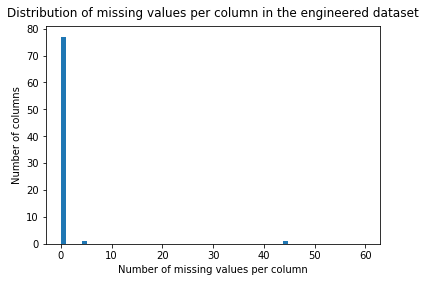

```python
plt.hist(final_data.isnull().sum(axis = 0), bins = np.linspace(0, 60, 60))
plt.xlabel('Number of missing values per column')
plt.ylabel('Number of columns')
plt.title('Distribution of missing values per column in the engineered dataset')
plt.show()
```

As we can see, in our engineered dataset, the vast majority of columns don't have missing values. The few colums that do have missing values have a small amount of them compared to the size of the dataset.

### Step 1.3: Create a Cleaning Function

Even though you've finished cleaning up the general population demographics data, it's important to look ahead to the future and realize that you'll need to perform the same cleaning steps on the customer demographics data. In this substep, complete the function below to execute the main feature selection, encoding, and re-engineering steps you performed above. Then, when it comes to looking at the customer data in Step 3, you can just run this function on that DataFrame to get the trimmed dataset in a single step.

```python
"""Utils functions"""
def split_numbers(val):
    return [int(d) for d in str(val)]

def get_digit(val, idx):
    return split_numbers(val)[idx]
```

```python
def convert_missing_values_to_nan(df):
    """Convert the missing values of a dataframe to nans"""

    # Create a dictionary with the columns names associated with their list of missing values encodings
    missing_encodings = {feat_info["attribute"][i]: convert_encodings(feat_info["missing_or_unknown"][i])
                         for i in range(len(feat_info))}

    mask = df.isin(missing_encodings) == False
    df = df[mask]
    return df
```

```python
def get_columns_to_drop_and_to_dummy(df):
    #Get the clumns to drop and to dummy. For simplicity, we choose the same columns as the general customer data.

    # columns_with_multi_cat_values_to_drop = ['GFK_URLAUBERTYP', 'LP_FAMILIE_FEIN', 'LP_STATUS_FEIN', 'CAMEO_DEUG_2015', 'CAMEO_DEU_2015']
    columns_with_multi_cat_values_to_drop = ['GFK_URLAUBERTYP', 'LP_FAMILIE_FEIN', 'LP_STATUS_FEIN', 'GEBAEUDETYP', 'CAMEO_DEUG_2015', 'CAMEO_DEU_2015']
    columns_to_dummy = ['CJT_GESAMTTYP', 'FINANZTYP', 'LP_FAMILIE_GROB', 'LP_STATUS_GROB', 'NATIONALITAET_KZ', 'SHOPPER_TYP', 'VERS_TYP', 'ZABEOTYP']
    columns_with_unique_value = ['ANZ_TITEL', 'ANZ_HAUSHALTE_AKTIV', 'ANZ_HH_TITEL', 'ANZ_PERSONEN', 'SOHO_KZ']
    columns_with_third_missing_values =  ['AGER_TYP', 'GEBURTSJAHR', 'TITEL_KZ', 'ALTER_HH', 'KK_KUNDENTYP', 'KBA05_BAUMAX']

    columns_to_drop = columns_with_multi_cat_values_to_drop + columns_with_unique_value + columns_with_third_missing_values

    return columns_to_drop, columns_to_dummy
```

```python
def drop_rows(df):
    """Drop rows from a dataframe that contain a number of missing values higher than a selected threshold"""
    threshold = 5
    data, _ = split_data(df, threshold)
    return data
```

```python
def engineer_df(df):
    """Engineer the different columns containing categorial values in the original dataframe"""
    avant_garde_values = [2.0, 4.0, 6.0, 7.0, 9.0, 11.0, 13.0, 15.0]
    mainstream_values = [1.0, 3.0, 5.0, 8.0, 10.0, 12.0, 14.0]

    def convert_to_binary(val):
        if val in avant_garde_values:
            return 1
        elif val in mainstream_values:
            return 0
        else:
            raise ValueError('Wrong value for {}'.format(val))

    values_to_decade_dict = {1: 40, 2: 40, 3: 50, 4: 50, 5: 60, 6: 60, 7: 60,
                             8: 70, 9: 70, 10: 80, 11: 80, 12: 80, 13: 80, 14: 90, 15: 90}

    # Engineer 'PRAEGENDE_JUGENDJAHRE_MOVEMENT'
    df['PRAEGENDE_JUGENDJAHRE_MOVEMENT'] = df['PRAEGENDE_JUGENDJAHRE'].apply(lambda val: val if np.isnan(val) else convert_to_binary(val))
    df['PRAEGENDE_JUGENDJAHRE_DECADE'] = df['PRAEGENDE_JUGENDJAHRE'].apply(lambda val: val if np.isnan(val) else values_to_decade_dict[val])
    df = df.drop('PRAEGENDE_JUGENDJAHRE', axis=1)

    # Engineer 'CAMEO_INTL_2015_WEALTH'
    df['CAMEO_INTL_2015_WEALTH'] = df['CAMEO_INTL_2015'].apply(lambda val: val if pd.isnull(val) else get_digit(val, 0))
    df['CAMEO_INTL_2015_LIFE_STAGE'] = df['CAMEO_INTL_2015'].apply(lambda val: val if pd.isnull(val) else get_digit(val, 1))
    df = df.drop('CAMEO_INTL_2015', axis=1)

    # Drop the other columns with mixed values
    columns_with_mixed_values = list(feat_info.loc[feat_info['type']=='mixed']['attribute'])
    columns_with_mixed_values = [col for col in columns_with_mixed_values if col not in ['CAMEO_INTL_2015', 'PRAEGENDE_JUGENDJAHRE', 'KBA05_BAUMAX', 'GEBAEUDETYP']]
    df = df.drop(columns_with_mixed_values, axis=1)

    return df
```

```python
def clean_data(df):
    """
    Perform feature trimming, re-encoding, and engineering for demographics
    data

    INPUT: Demographics DataFrame
    OUTPUT: Trimmed and cleaned demographics DataFrame
    """

    # Put in code here to execute all main cleaning steps:
    # convert missing value codes into NaNs, ...
    df = convert_missing_values_to_nan(df)
    # remove selected columns and rows, ...
    df = drop_rows(df)

    columns_to_drop, columns_to_dummy = get_columns_to_drop_and_to_dummy(df)

    df = df.drop(columns_to_drop, axis=1)

    df = pd.get_dummies(
             df.replace({'OST_WEST_KZ': {'W': 1, 'O': 0}}),
             prefix=columns_to_dummy,
             columns=columns_to_dummy
             )

    # select, re-encode, and engineer column values.
    df = engineer_df(df)

    # Return the cleaned dataframe.
    return df
```

## Step 2: Feature Transformation

### Step 2.1: Apply Feature Scaling

Before we apply dimensionality reduction techniques to the data, we need to perform feature scaling so that the principal component vectors are not influenced by the natural differences in scale for features. Starting from this part of the project, you'll want to keep an eye on the [API reference page for sklearn](http://scikit-learn.org/stable/modules/classes.html) to help you navigate to all of the classes and functions that you'll need. In this substep, you'll need to check the following:

- sklearn requires that data not have missing values in order for its estimators to work properly. So, before applying the scaler to your data, make sure that you've cleaned the DataFrame of the remaining missing values. This can be as simple as just removing all data points with missing data, or applying an [Imputer](http://scikit-learn.org/stable/modules/generated/sklearn.preprocessing.Imputer.html) to replace all missing values. You might also try a more complicated procedure where you temporarily remove missing values in order to compute the scaling parameters before re-introducing those missing values and applying imputation. Think about how much missing data you have and what possible effects each approach might have on your analysis, and justify your decision in the discussion section below.
- For the actual scaling function, a [StandardScaler](http://scikit-learn.org/stable/modules/generated/sklearn.preprocessing.StandardScaler.html) instance is suggested, scaling each feature to mean 0 and standard deviation 1.
- For these classes, you can make use of the `.fit_transform()` method to both fit a procedure to the data as well as apply the transformation to the data at the same time. Don't forget to keep the fit sklearn objects handy, since you'll be applying them to the customer demographics data towards the end of the project.

```python
# If you've not yet cleaned the dataset of all NaN values, then investigate and
# do that now.
imp_mean = Imputer(missing_values="NaN", strategy='mean')
imputed_data = imp_mean.fit_transform(final_data)
```

```python
# Verify that the missing values have been converted
pd.DataFrame(imputed_data).isnull().sum().sum()
```

```
0
```

```python
# Apply feature scaling to the general population demographics data.
scaler = StandardScaler()
scaled_data = scaler.fit_transform(imputed_data) # Fit and transform the data
```

### Step 2.2: Perform Dimensionality Reduction

On your scaled data, you are now ready to apply dimensionality reduction techniques.

- Use sklearn's [PCA](http://scikit-learn.org/stable/modules/generated/sklearn.decomposition.PCA.html) class to apply principal component analysis on the data, thus finding the vectors of maximal variance in the data. To start, you should not set any parameters (so all components are computed) or set a number of components that is at least half the number of features (so there's enough features to see the general trend in variability).
- Check out the ratio of variance explained by each principal component as well as the cumulative variance explained. Try plotting the cumulative or sequential values using matplotlib's [`plot()`](https://matplotlib.org/api/_as_gen/matplotlib.pyplot.plot.html) function. Based on what you find, select a value for the number of transformed features you'll retain for the clustering part of the project.
- Once you've made a choice for the number of components to keep, make sure you re-fit a PCA instance to perform the decided-on transformation.

```python
def pca_results(full_dataset, pca):
    '''
    Create a DataFrame of the PCA results
    Includes dimension feature weights and explained variance
    Visualizes the PCA results
    '''

    # Dimension indexing
    dimensions = ['Dimension {}'.format(i) for i in range(1, len(pca.components_)+1)]

    # PCA components
    components = pd.DataFrame(np.round(pca.components_, 4), columns = full_dataset.keys())
    components.index = dimensions

    # PCA explained variance
    ratios = pca.explained_variance_ratio_.reshape(len(pca.components_), 1)
    variance_ratios = pd.DataFrame(np.round(ratios, 4), columns=['Explained Variance'])
    variance_ratios.index = dimensions

    # Return a concatenated DataFrame
    return pd.concat([variance_ratios, components], axis=1)
```

```python
# Apply PCA to the data.
pca = PCA()
pca = pca.fit(scaled_data)
```

```python
# Investigate the variance accounted for by each principal component.
pca_results(final_data, pca)
```

|  | Explained Variance | ALTERSKATEGORIE_GROB | ANREDE_KZ | FINANZ_MINIMALIST | FINANZ_SPARER | FINANZ_VORSORGER | FINANZ_ANLEGER | FINANZ_UNAUFFAELLIGER | FINANZ_HAUSBAUER | GREEN_AVANTGARDE | ... | ZABEOTYP_1 | ZABEOTYP_2 | ZABEOTYP_3 | ZABEOTYP_4 | ZABEOTYP_5 | ZABEOTYP_6 | PRAEGENDE_JUGENDJAHRE_MOVEMENT | PRAEGENDE_JUGENDJAHRE_DECADE | CAMEO_INTL_2015_WEALTH | CAMEO_INTL_2015_LIFE_STAGE |
| --- | --- | --- | --- | --- | --- | --- | --- | --- | --- | --- | --- | --- | --- | --- | --- | --- | --- | --- | --- | --- | --- |
| Dimension 1 | 0.1342 | -0.1612 | 0.0027 | -0.2233 | 0.1843 | -0.1517 | 0.1102 | 0.1195 | 0.1256 | -0.1052 | ... | -0.0848 | -0.0390 | -0.0755 | 0.0700 | 0.1089 | 0.0343 | -0.1054 | 0.1495 | 0.1689 | -0.1115 |
| Dimension 2 | 0.1083 | -0.1978 | -0.0693 | -0.0063 | 0.1794 | -0.1835 | 0.1718 | 0.1905 | -0.1470 | 0.0512 | ... | 0.1035 | 0.0445 | -0.1962 | 0.0860 | 0.0633 | -0.0316 | 0.0491 | 0.2022 | -0.1194 | 0.0317 |
| Dimension 3 | 0.0700 | 0.0440 | -0.3514 | 0.1296 | -0.0728 | 0.0714 | -0.1656 | -0.0677 | -0.0402 | 0.0494 | ... | 0.1018 | -0.0302 | -0.0096 | -0.0720 | -0.0350 | 0.0551 | 0.0497 | -0.0783 | 0.0333 | -0.0177 |
| Dimension 4 | 0.0436 | -0.0272 | 0.0643 | 0.0321 | 0.0002 | -0.0148 | -0.1083 | 0.0868 | -0.0646 | 0.3604 | ... | 0.1043 | 0.1171 | -0.0749 | -0.0238 | -0.0165 | -0.0283 | 0.3600 | 0.0310 | -0.0867 | 0.0418 |
| Dimension 5 | 0.0293 | -0.0240 | 0.0242 | -0.1170 | 0.0037 | 0.0492 | -0.0589 | 0.1095 | 0.1536 | 0.0094 | ... | 0.0044 | -0.0807 | 0.0483 | -0.1194 | 0.1049 | 0.0366 | 0.0109 | -0.0402 | -0.0360 | 0.0184 |
| Dimension 6 | 0.0252 | 0.0157 | 0.0740 | -0.0293 | -0.0263 | -0.0367 | 0.0122 | -0.0284 | 0.1043 | 0.0271 | ... | 0.0516 | 0.0102 | -0.0067 | -0.0726 | 0.0493 | -0.0021 | 0.0273 | -0.0493 | 0.0086 | 0.0358 |
| Dimension 7 | 0.0227 | 0.1007 | -0.0211 | -0.1084 | 0.0605 | 0.0160 | 0.0704 | 0.0788 | 0.1007 | -0.0293 | ... | 0.0060 | -0.0527 | 0.0111 | 0.1875 | -0.0496 | -0.2257 | -0.0287 | 0.0281 | 0.0469 | -0.0174 |
| Dimension 8 | 0.0219 | -0.0085 | 0.0059 | 0.1243 | -0.1083 | 0.1054 | -0.0804 | -0.1665 | -0.1323 | -0.1023 | ... | -0.0089 | 0.0432 | -0.0453 | 0.0290 | -0.1831 | 0.2103 | -0.1032 | -0.0758 | 0.0407 | -0.0667 |
| Dimension 9 | 0.0204 | 0.0385 | -0.0198 | -0.0440 | 0.0505 | -0.1201 | 0.0960 | -0.0849 | 0.0130 | 0.0191 | ... | 0.0101 | 0.1015 | -0.0379 | -0.0720 | 0.0341 | 0.0582 | 0.0200 | 0.0818 | -0.0150 | 0.0241 |
| Dimension 10 | 0.0188 | -0.0769 | 0.0365 | -0.0482 | -0.0427 | 0.1040 | -0.0368 | -0.0620 | 0.1352 | -0.0139 | ... | 0.0803 | -0.0601 | -0.0132 | 0.0012 | -0.0513 | 0.0128 | -0.0122 | -0.0686 | -0.0627 | 0.0528 |
| Dimension 11 | 0.0185 | 0.0047 | -0.0083 | -0.0601 | -0.0279 | 0.0579 | -0.0096 | -0.0646 | 0.1348 | 0.0193 | ... | -0.0288 | -0.0392 | -0.0023 | 0.0629 | -0.1042 | 0.0808 | 0.0182 | -0.0264 | 0.0295 | 0.0387 |
| Dimension 12 | 0.0174 | 0.1561 | -0.0469 | 0.0294 | 0.0461 | -0.1243 | -0.0493 | 0.1696 | -0.1419 | -0.0827 | ... | -0.1068 | -0.0344 | 0.0077 | 0.1454 | -0.0185 | -0.0586 | -0.0820 | 0.0781 | 0.0047 | -0.0742 |
| Dimension 13 | 0.0164 | 0.0204 | 0.0042 | -0.0024 | 0.0526 | -0.1210 | 0.1074 | -0.0145 | 0.0181 | 0.1430 | ... | -0.0422 | 0.0053 | 0.0991 | -0.0712 | 0.1264 | -0.1419 | 0.1426 | 0.0186 | 0.0428 | 0.0372 |
| Dimension 14 | 0.0152 | -0.0142 | 0.0355 | 0.0338 | -0.0114 | -0.0148 | -0.0122 | 0.0516 | -0.0067 | -0.0635 | ... | 0.1432 | 0.1309 | 0.0117 | -0.3037 | 0.1841 | -0.0172 | -0.0633 | -0.0095 | 0.0852 | -0.1150 |
| Dimension 15 | 0.0149 | -0.0621 | 0.0366 | -0.0189 | -0.0772 | 0.0513 | -0.0363 | -0.0351 | 0.1601 | -0.0498 | ... | -0.0887 | 0.1058 | -0.0810 | 0.2176 | -0.1538 | 0.0099 | -0.0482 | -0.0837 | -0.0649 | 0.1581 |
| Dimension 16 | 0.0141 | -0.0234 | 0.0131 | 0.0408 | -0.0026 | -0.0124 | -0.0382 | -0.0219 | -0.0078 | -0.1976 | ... | 0.0608 | -0.0252 | -0.0322 | 0.0587 | 0.0440 | -0.1435 | -0.1999 | -0.0113 | -0.0598 | 0.0648 |
| Dimension 17 | 0.0137 | -0.0450 | 0.0284 | 0.0071 | -0.0052 | -0.0704 | 0.0233 | 0.0166 | 0.0270 | -0.0810 | ... | -0.0100 | -0.0675 | 0.0415 | 0.0076 | 0.0018 | -0.0264 | -0.0810 | 0.0080 | -0.0462 | 0.0519 |
| Dimension 18 | 0.0136 | -0.0706 | 0.0352 | 0.0501 | -0.0506 | 0.0060 | -0.0429 | -0.0186 | 0.0294 | -0.0584 | ... | 0.0200 | -0.0106 | 0.0829 | -0.0424 | 0.0170 | -0.1098 | -0.0591 | -0.0505 | 0.0016 | 0.0050 |
| Dimension 19 | 0.0131 | 0.0698 | -0.0610 | -0.0170 | 0.0233 | -0.0719 | -0.0064 | 0.0655 | 0.0291 | -0.0323 | ... | -0.1018 | 0.2284 | 0.1052 | -0.1823 | 0.2233 | -0.1557 | -0.0319 | 0.0208 | -0.0439 | 0.0448 |
| Dimension 20 | 0.0130 | 0.0204 | 0.0053 | 0.0458 | -0.0150 | -0.0254 | 0.0319 | 0.0181 | -0.0060 | 0.0874 | ... | 0.0212 | -0.0541 | 0.0063 | 0.0607 | -0.0442 | -0.0476 | 0.0898 | -0.0009 | 0.0939 | -0.1494 |
| Dimension 21 | 0.0129 | 0.0062 | -0.0016 | 0.0050 | 0.0018 | -0.0494 | -0.0434 | 0.0571 | -0.0232 | -0.1236 | ... | -0.0250 | 0.1099 | 0.0569 | -0.1799 | 0.1233 | 0.0085 | -0.1222 | 0.0097 | -0.0304 | 0.1279 |
| Dimension 22 | 0.0122 | -0.0299 | 0.0305 | -0.0019 | 0.0033 | 0.0310 | 0.0524 | -0.0101 | 0.0007 | 0.0409 | ... | -0.0585 | 0.1924 | -0.0134 | 0.0262 | -0.0717 | 0.0078 | 0.0415 | -0.0186 | 0.0368 | -0.0947 |
| Dimension 23 | 0.0121 | 0.0605 | 0.0021 | -0.0537 | 0.0046 | 0.0625 | 0.0132 | -0.0916 | 0.0934 | 0.0123 | ... | 0.1431 | -0.1833 | 0.0464 | -0.0078 | 0.0440 | -0.1738 | 0.0131 | -0.0300 | -0.0631 | 0.0401 |
| Dimension 24 | 0.0117 | -0.0410 | 0.0044 | 0.0209 | -0.0491 | 0.0441 | -0.0285 | 0.0052 | 0.0046 | 0.0043 | ... | -0.0298 | 0.1039 | -0.1667 | 0.1101 | -0.1028 | 0.1897 | 0.0029 | -0.0282 | 0.0188 | -0.0257 |
| Dimension 25 | 0.0114 | -0.0204 | 0.0103 | -0.0055 | -0.0043 | 0.0054 | 0.0072 | -0.0494 | -0.0197 | -0.0091 | ... | 0.0802 | -0.0389 | -0.1349 | -0.0995 | 0.0693 | 0.2272 | -0.0119 | 0.0247 | -0.0678 | 0.0979 |
| Dimension 26 | 0.0114 | 0.0016 | -0.0332 | -0.0591 | 0.0302 | 0.0276 | 0.0180 | -0.0002 | 0.0419 | -0.0032 | ... | -0.2958 | 0.3153 | 0.0856 | 0.0209 | -0.0163 | 0.0107 | -0.0034 | 0.0064 | -0.0506 | 0.0405 |
| Dimension 27 | 0.0111 | -0.0364 | 0.0333 | -0.0142 | -0.0139 | 0.0291 | 0.0008 | -0.0085 | 0.0185 | -0.0480 | ... | 0.0039 | 0.1061 | 0.1259 | -0.0792 | -0.0169 | -0.1445 | -0.0478 | -0.0157 | -0.1120 | 0.0763 |
| Dimension 28 | 0.0109 | 0.0452 | -0.0582 | 0.0119 | -0.0492 | 0.0015 | -0.0447 | 0.0082 | 0.0508 | 0.0046 | ... | -0.0460 | 0.0614 | -0.1117 | 0.1031 | -0.0421 | 0.0916 | 0.0045 | -0.0267 | -0.0885 | 0.1053 |
| Dimension 29 | 0.0108 | 0.0533 | 0.0048 | -0.0062 | 0.0136 | 0.0175 | 0.0170 | 0.0108 | -0.0406 | -0.0001 | ... | 0.0984 | -0.1217 | -0.0880 | -0.1388 | 0.1134 | 0.1926 | 0.0005 | 0.0543 | 0.0842 | -0.1080 |
| Dimension 30 | 0.0107 | 0.0080 | 0.0127 | -0.0187 | 0.0516 | 0.0103 | 0.0752 | 0.0052 | -0.0670 | 0.0157 | ... | -0.0527 | 0.0509 | 0.0299 | -0.1276 | 0.0255 | 0.1514 | 0.0151 | 0.0699 | 0.0356 | -0.1630 |
| ... | ... | ... | ... | ... | ... | ... | ... | ... | ... | ... | ... | ... | ... | ... | ... | ... | ... | ... | ... | ... | ... |
| Dimension 66 | 0.0024 | 0.0940 | -0.0241 | 0.0212 | -0.0372 | -0.0382 | -0.1762 | -0.0484 | -0.2078 | 0.0433 | ... | -0.0714 | -0.0474 | 0.0270 | 0.0196 | 0.0301 | 0.0133 | 0.0426 | -0.1170 | 0.1432 | 0.0134 |
| Dimension 67 | 0.0023 | -0.0502 | 0.0156 | 0.0512 | -0.0431 | 0.0748 | 0.1424 | -0.0204 | 0.1958 | -0.0491 | ... | -0.0667 | -0.0584 | -0.0352 | 0.0624 | 0.0618 | 0.0188 | -0.0481 | 0.0653 | 0.2916 | 0.0798 |
| Dimension 68 | 0.0022 | 0.0287 | -0.0125 | -0.0365 | -0.0177 | -0.1373 | -0.1667 | 0.1255 | 0.1615 | 0.0027 | ... | 0.0464 | 0.0274 | -0.0143 | -0.0134 | -0.0460 | 0.0175 | 0.0056 | 0.0715 | -0.0126 | -0.0142 |
| Dimension 69 | 0.0021 | -0.0728 | 0.0627 | 0.0583 | -0.0165 | 0.1010 | 0.0478 | -0.0309 | -0.2486 | 0.0071 | ... | -0.0387 | -0.0174 | 0.0053 | 0.0199 | 0.0329 | -0.0145 | 0.0028 | -0.0891 | -0.0341 | -0.0113 |
| Dimension 70 | 0.0020 | -0.0225 | -0.0173 | -0.0380 | -0.0160 | 0.2660 | 0.1873 | 0.1934 | 0.2790 | -0.0590 | ... | -0.0063 | -0.0128 | -0.0364 | 0.0304 | 0.0378 | -0.0101 | -0.0521 | 0.1902 | 0.0477 | 0.0242 |
| Dimension 71 | 0.0019 | -0.0775 | 0.1033 | 0.0269 | -0.1560 | -0.1227 | -0.3166 | 0.5989 | 0.1121 | -0.0174 | ... | 0.0013 | -0.0082 | -0.0023 | 0.0114 | -0.0361 | 0.0286 | -0.0124 | 0.0643 | 0.0171 | -0.0130 |
| Dimension 72 | 0.0018 | 0.0282 | -0.0441 | -0.0474 | 0.0913 | -0.0520 | 0.0617 | 0.1261 | 0.1762 | -0.0313 | ... | -0.0252 | -0.0131 | 0.0858 | -0.0552 | -0.0327 | 0.0165 | -0.0314 | -0.0467 | 0.0286 | 0.0153 |
| Dimension 73 | 0.0018 | 0.0808 | -0.0772 | 0.0124 | 0.0567 | -0.0212 | -0.0915 | -0.1477 | 0.1189 | -0.0288 | ... | -0.0052 | -0.0074 | 0.0213 | -0.0077 | -0.0192 | 0.0082 | -0.0232 | 0.1816 | 0.0414 | 0.0272 |
| Dimension 74 | 0.0018 | -0.0973 | 0.0613 | -0.0010 | -0.0290 | 0.1252 | 0.1902 | -0.0247 | -0.1074 | 0.0135 | ... | -0.0013 | 0.0041 | -0.0292 | 0.0168 | 0.0375 | -0.0182 | 0.0082 | -0.1135 | -0.0203 | -0.0087 |
| Dimension 75 | 0.0017 | -0.0633 | 0.0245 | -0.0143 | 0.0057 | 0.0644 | 0.0760 | -0.1515 | -0.0040 | -0.0208 | ... | 0.0139 | 0.0015 | -0.0081 | 0.0051 | 0.0019 | -0.0147 | -0.0191 | 0.1124 | 0.0001 | -0.0210 |
| Dimension 76 | 0.0016 | 0.0918 | -0.0412 | -0.0269 | 0.0911 | -0.1062 | 0.2807 | 0.3247 | -0.0657 | 0.0170 | ... | 0.0036 | 0.0112 | -0.0631 | -0.0074 | 0.0593 | 0.0411 | -0.0133 | -0.7339 | -0.0086 | -0.0133 |
| Dimension 77 | 0.0015 | 0.1251 | -0.0770 | -0.0492 | 0.0409 | -0.0049 | -0.0701 | -0.0080 | 0.0986 | 0.0195 | ... | 0.0030 | 0.0068 | 0.0182 | -0.0126 | -0.0251 | 0.0076 | 0.0211 | 0.0838 | -0.0217 | -0.0223 |
| Dimension 78 | 0.0015 | -0.0406 | -0.0096 | 0.1177 | -0.1846 | 0.2398 | 0.1797 | 0.1482 | -0.0933 | 0.0089 | ... | 0.0092 | 0.0073 | -0.0162 | 0.0075 | 0.0273 | -0.0300 | 0.0136 | 0.0900 | 0.0171 | 0.0030 |
| Dimension 79 | 0.0014 | -0.0150 | -0.0143 | 0.2674 | -0.3395 | 0.3503 | 0.2156 | 0.3073 | -0.1235 | 0.0083 | ... | -0.0144 | -0.0058 | -0.0029 | 0.0199 | 0.0310 | -0.0369 | 0.0175 | 0.2136 | -0.0337 | -0.0146 |
| Dimension 80 | 0.0013 | 0.0040 | 0.0157 | -0.0931 | 0.0837 | -0.0233 | -0.0633 | -0.0401 | 0.0210 | 0.0011 | ... | -0.0031 | 0.0038 | -0.0011 | 0.0005 | -0.0055 | 0.0086 | -0.0026 | -0.0307 | -0.0032 | -0.0020 |
| Dimension 81 | 0.0012 | 0.4673 | -0.2581 | 0.1844 | 0.0774 | 0.0031 | 0.0556 | 0.0556 | 0.0860 | -0.0020 | ... | -0.0159 | -0.0071 | 0.0600 | -0.0289 | -0.0267 | -0.0027 | 0.0110 | 0.0482 | -0.0094 | 0.0076 |
| Dimension 82 | 0.0011 | -0.5220 | 0.0768 | -0.1721 | 0.0572 | 0.0400 | -0.1296 | -0.0115 | -0.0965 | 0.0018 | ... | 0.0035 | -0.0009 | -0.0374 | 0.0196 | 0.0185 | 0.0088 | -0.0079 | -0.1057 | -0.0081 | -0.0144 |
| Dimension 83 | 0.0010 | 0.1989 | -0.0649 | -0.5354 | 0.2899 | 0.5453 | -0.1799 | 0.1374 | -0.2558 | -0.0179 | ... | -0.0086 | 0.0108 | 0.0028 | -0.0059 | 0.0203 | -0.0135 | -0.0136 | 0.0201 | 0.0127 | 0.0037 |
| Dimension 84 | 0.0009 | 0.0977 | -0.0093 | -0.3145 | -0.4857 | -0.2054 | 0.1301 | -0.0413 | -0.0741 | -0.0075 | ... | -0.0003 | 0.0047 | -0.0028 | 0.0042 | -0.0025 | -0.0019 | -0.0038 | 0.0309 | 0.0205 | -0.0024 |
| Dimension 85 | 0.0008 | 0.1457 | -0.0305 | -0.4685 | -0.4870 | -0.1506 | 0.1023 | -0.0502 | -0.1376 | -0.0122 | ... | -0.0062 | 0.0054 | 0.0023 | 0.0024 | 0.0005 | -0.0036 | -0.0069 | 0.0314 | 0.0012 | -0.0081 |
| Dimension 86 | 0.0008 | -0.1584 | -0.0901 | -0.0499 | -0.0819 | -0.0642 | 0.0483 | -0.0431 | 0.0050 | 0.0005 | ... | -0.0125 | -0.0081 | 0.0436 | -0.0108 | -0.0202 | -0.0136 | 0.0033 | 0.0116 | 0.0012 | -0.0036 |
| Dimension 87 | 0.0005 | -0.2872 | -0.7253 | -0.0412 | -0.0285 | -0.0179 | 0.0254 | 0.0063 | 0.0235 | 0.0091 | ... | -0.0001 | -0.0032 | -0.0044 | -0.0009 | 0.0073 | 0.0033 | 0.0013 | -0.0455 | 0.0033 | -0.0033 |
| Dimension 88 | 0.0005 | -0.1353 | -0.3746 | -0.0379 | -0.0418 | -0.0001 | 0.0119 | -0.0007 | 0.0030 | 0.0053 | ... | 0.0030 | 0.0033 | 0.0028 | 0.0019 | -0.0079 | -0.0051 | -0.0030 | 0.0135 | -0.0001 | -0.0025 |
| Dimension 89 | 0.0000 | -0.0088 | -0.0102 | 0.0013 | -0.0009 | 0.0020 | -0.0014 | 0.0011 | -0.0010 | 0.0016 | ... | -0.0004 | -0.0005 | 0.0001 | 0.0001 | 0.0006 | -0.0003 | -0.0016 | 0.0006 | -0.0001 | -0.0004 |
| Dimension 90 | 0.0000 | -0.0101 | -0.0034 | -0.0007 | 0.0064 | -0.0051 | 0.0032 | 0.0015 | -0.0047 | -0.7079 | ... | -0.0004 | -0.0003 | -0.0022 | -0.0002 | 0.0020 | 0.0026 | 0.7057 | -0.0226 | -0.0010 | -0.0012 |
| Dimension 91 | 0.0000 | -0.0000 | -0.0000 | 0.0000 | -0.0000 | -0.0000 | -0.0000 | -0.0000 | -0.0000 | -0.0000 | ... | 0.0243 | 0.0125 | 0.0321 | 0.0295 | 0.0206 | 0.0193 | 0.0000 | -0.0000 | 0.0000 | -0.0000 |
| Dimension 92 | 0.0000 | -0.0000 | 0.0000 | 0.0000 | 0.0000 | -0.0000 | 0.0000 | -0.0000 | -0.0000 | 0.0000 | ... | -0.0082 | -0.0042 | -0.0108 | -0.0100 | -0.0070 | -0.0065 | 0.0000 | -0.0000 | 0.0000 | -0.0000 |
| Dimension 93 | 0.0000 | -0.0000 | 0.0000 | -0.0000 | 0.0000 | 0.0000 | 0.0000 | 0.0000 | 0.0000 | 0.0000 | ... | 0.0034 | 0.0018 | 0.0045 | 0.0042 | 0.0029 | 0.0027 | -0.0000 | -0.0000 | 0.0000 | -0.0000 |
| Dimension 94 | 0.0000 | -0.0000 | -0.0000 | 0.0000 | -0.0000 | -0.0000 | 0.0000 | -0.0000 | 0.0000 | 0.0000 | ... | -0.0015 | -0.0008 | -0.0020 | -0.0018 | -0.0013 | -0.0012 | -0.0000 | 0.0000 | -0.0000 | 0.0000 |
| Dimension 95 | 0.0000 | 0.0000 | -0.0000 | -0.0000 | -0.0000 | 0.0000 | 0.0000 | -0.0000 | -0.0000 | -0.0000 | ... | 0.4127 | 0.2126 | 0.5464 | 0.5014 | 0.3509 | 0.3278 | 0.0000 | 0.0000 | -0.0000 | -0.0000 |

95 rows × 96 columns

```python
n_components_list = list(range(20, 80))
for num in n_components_list:
    pca = PCA(n_components=num)
    pca = pca.fit(scaled_data)
    explained_variance = np.sum(pca.explained_variance_ratio_)
    if explained_variance >= 0.95:
        print("The minimum number of components explaining 95 % of the variance is ", num)
        break
```

```
The minimum number of components explaining 95 % of the variance is  60
```

```python
# Re-apply PCA to the data while selecting for number of components to retain.
pca = PCA(n_components=60)
pca = pca.fit(scaled_data)
data_pca = pca.transform(scaled_data)
```

```python
print(scaled_data.shape)
print(data_pca.shape)
```

```
(722258, 95)
(722258, 60)
```

### Discussion 2.2: Perform Dimensionality Reduction

For our analysis, we decided to keep 95 % of the explained variance, which resulted into 60 components. From our original dataset, that had 95 components, this is a reduction of approximately 36 %. That redution in the overall size of our dataset will greatly reduce computation time, while keeping most (95 %) of the information from the original data. That is even more important in our case, considering that we have a pretty large dataset, having initially hundreds of thousands of rows.

### Step 2.3: Interpret Principal Components

Now that we have our transformed principal components, it's a nice idea to check out the weight of each variable on the first few components to see if they can be interpreted in some fashion.

As a reminder, each principal component is a unit vector that points in the direction of highest variance (after accounting for the variance captured by earlier principal components). The further a weight is from zero, the more the principal component is in the direction of the corresponding feature. If two features have large weights of the same sign (both positive or both negative), then increases in one tend expect to be associated with increases in the other. To contrast, features with different signs can be expected to show a negative correlation: increases in one variable should result in a decrease in the other.

- To investigate the features, you should map each weight to their corresponding feature name, then sort the features according to weight. The most interesting features for each principal component, then, will be those at the beginning and end of the sorted list. Use the data dictionary document to help you understand these most prominent features, their relationships, and what a positive or negative value on the principal component might indicate.
- You should investigate and interpret feature associations from the first three principal components in this substep. To help facilitate this, you should write a function that you can call at any time to print the sorted list of feature weights, for the *i*-th principal component. This might come in handy in the next step of the project, when you interpret the tendencies of the discovered clusters.

```python
# Map weights for the first principal component to corresponding feature names
# and then print the linked values, sorted by weight.
# HINT: Try defining a function here or in a new cell that you can reuse in the
# other cells.

pca_ratios_df = pca_results(final_data, pca)

def map_component_to_weights(pca_ratios_df, component_rank):
    """Take a component out of dafaframe of pca ratios and return a dictionnary
        sorted by the weights of the selected component"""
    return sorted(pca_ratios_df.iloc[component_rank - 1].to_dict().items(), key=lambda kv: kv[1], reverse=True)


def dataframe_of_weights_map(pca_ratios_df, component_rank):
    weights_map = map_component_to_weights(pca_ratios_df, component_rank)
    attributes = [elem[0] for elem in weights_map]
    weights = [elem[1] for elem in weights_map]
    return pd.DataFrame.from_dict({'Attributes': attributes, 'Weights': weights})

first_component_dataframe = dataframe_of_weights_map(pca_ratios_df, 1)
first_component_dataframe
```

|  | Attributes | Weights |
| --- | --- | --- |
| 0 | LP_STATUS_GROB_1.0 | 0.1957 |
| 1 | FINANZ_SPARER | 0.1843 |
| 2 | HH_EINKOMMEN_SCORE | 0.1793 |
| 3 | PLZ8_ANTG3 | 0.1779 |
| 4 | PLZ8_ANTG4 | 0.1708 |
| 5 | CAMEO_INTL_2015_WEALTH | 0.1689 |
| 6 | FINANZTYP_1 | 0.1539 |
| 7 | ORTSGR_KLS9 | 0.1515 |
| 8 | EWDICHTE | 0.1499 |
| 9 | PRAEGENDE_JUGENDJAHRE_DECADE | 0.1495 |
| 10 | SEMIO_PFLICHT | 0.1473 |
| 11 | SEMIO_REL | 0.1428 |
| 12 | Explained Variance | 0.1342 |
| 13 | SEMIO_TRADV | 0.1297 |
| 14 | FINANZ_HAUSBAUER | 0.1256 |
| 15 | SEMIO_RAT | 0.1247 |
| 16 | PLZ8_ANTG2 | 0.1219 |
| 17 | FINANZ_UNAUFFAELLIGER | 0.1195 |
| 18 | KBA05_ANTG4 | 0.1181 |
| 19 | KBA05_ANTG3 | 0.1173 |
| 20 | ARBEIT | 0.1104 |
| 21 | FINANZ_ANLEGER | 0.1102 |
| 22 | ZABEOTYP_5 | 0.1089 |
| 23 | RELAT_AB | 0.1035 |
| 24 | SEMIO_MAT | 0.0989 |
| 25 | SEMIO_KULT | 0.0958 |
| 26 | SEMIO_FAM | 0.0924 |
| 27 | ZABEOTYP_4 | 0.0700 |
| 28 | NATIONALITAET_KZ_2.0 | 0.0668 |
| 29 | LP_FAMILIE_GROB_1.0 | 0.0651 |
| ... | ... | ... |
| 66 | LP_FAMILIE_GROB_5.0 | -0.0507 |
| 67 | FINANZTYP_6 | -0.0513 |
| 68 | SHOPPER_TYP_3.0 | -0.0541 |
| 69 | KBA13_ANZAHL_PKW | -0.0597 |
| 70 | RETOURTYP_BK_S | -0.0601 |
| 71 | WOHNDAUER_2008 | -0.0725 |
| 72 | ZABEOTYP_3 | -0.0755 |
| 73 | CJT_GESAMTTYP_2.0 | -0.0789 |
| 74 | NATIONALITAET_KZ_1.0 | -0.0841 |
| 75 | ZABEOTYP_1 | -0.0848 |
| 76 | GEBAEUDETYP_RASTER | -0.0898 |
| 77 | BALLRAUM | -0.0958 |
| 78 | GREEN_AVANTGARDE | -0.1052 |
| 79 | PRAEGENDE_JUGENDJAHRE_MOVEMENT | -0.1054 |
| 80 | SEMIO_ERL | -0.1082 |
| 81 | FINANZTYP_2 | -0.1089 |
| 82 | LP_STATUS_GROB_4.0 | -0.1106 |
| 83 | CAMEO_INTL_2015_LIFE_STAGE | -0.1115 |
| 84 | SEMIO_LUST | -0.1123 |
| 85 | LP_STATUS_GROB_5.0 | -0.1196 |
| 86 | INNENSTADT | -0.1259 |
| 87 | PLZ8_GBZ | -0.1295 |
| 88 | KONSUMNAEHE | -0.1303 |
| 89 | FINANZ_VORSORGER | -0.1517 |
| 90 | ALTERSKATEGORIE_GROB | -0.1612 |
| 91 | KBA05_GBZ | -0.1756 |
| 92 | PLZ8_ANTG1 | -0.1777 |
| 93 | KBA05_ANTG1 | -0.1870 |
| 94 | MOBI_REGIO | -0.1984 |
| 95 | FINANZ_MINIMALIST | -0.2233 |

96 rows × 2 columns

```python
# Map weights for the second principal component to corresponding feature names
# and then print the linked values, sorted by weight.
second_component_dataframe = dataframe_of_weights_map(pca_ratios_df, 2)
second_component_dataframe
```

|  | Attributes | Weights |
| --- | --- | --- |
| 0 | PRAEGENDE_JUGENDJAHRE_DECADE | 0.2022 |
| 1 | SEMIO_REL | 0.1979 |
| 2 | FINANZ_UNAUFFAELLIGER | 0.1905 |
| 3 | SEMIO_TRADV | 0.1846 |
| 4 | FINANZ_SPARER | 0.1794 |
| 5 | SEMIO_PFLICHT | 0.1772 |
| 6 | FINANZ_ANLEGER | 0.1718 |
| 7 | ONLINE_AFFINITAET | 0.1708 |
| 8 | SEMIO_KULT | 0.1681 |
| 9 | MOBI_REGIO | 0.1432 |
| 10 | PLZ8_ANTG1 | 0.1364 |
| 11 | KBA05_GBZ | 0.1352 |
| 12 | SEMIO_FAM | 0.1319 |
| 13 | KBA05_ANTG1 | 0.1319 |
| 14 | SEMIO_RAT | 0.1315 |
| 15 | SEMIO_MAT | 0.1146 |
| 16 | Explained Variance | 0.1083 |
| 17 | PLZ8_GBZ | 0.1041 |
| 18 | ZABEOTYP_1 | 0.1035 |
| 19 | INNENSTADT | 0.1015 |
| 20 | KONSUMNAEHE | 0.0993 |
| 21 | FINANZTYP_3 | 0.0919 |
| 22 | FINANZTYP_4 | 0.0913 |
| 23 | ZABEOTYP_4 | 0.0860 |
| 24 | FINANZTYP_1 | 0.0837 |
| 25 | BALLRAUM | 0.0794 |
| 26 | SEMIO_SOZ | 0.0730 |
| 27 | SHOPPER_TYP_0.0 | 0.0684 |
| 28 | LP_FAMILIE_GROB_4.0 | 0.0665 |
| 29 | GEBAEUDETYP_RASTER | 0.0640 |
| ... | ... | ... |
| 66 | SEMIO_DOM | -0.0538 |
| 67 | FINANZTYP_2 | -0.0587 |
| 68 | CJT_GESAMTTYP_1.0 | -0.0619 |
| 69 | ANREDE_KZ | -0.0693 |
| 70 | SHOPPER_TYP_3.0 | -0.0702 |
| 71 | LP_FAMILIE_GROB_1.0 | -0.0747 |
| 72 | KBA05_ANTG3 | -0.0793 |
| 73 | RELAT_AB | -0.0884 |
| 74 | CJT_GESAMTTYP_2.0 | -0.0897 |
| 75 | FINANZTYP_5 | -0.0902 |
| 76 | LP_STATUS_GROB_1.0 | -0.0936 |
| 77 | PLZ8_ANTG2 | -0.0945 |
| 78 | ARBEIT | -0.0948 |
| 79 | SEMIO_KAEM | -0.0952 |
| 80 | KBA05_ANTG4 | -0.0973 |
| 81 | SEMIO_KRIT | -0.1001 |
| 82 | HH_EINKOMMEN_SCORE | -0.1046 |
| 83 | CAMEO_INTL_2015_WEALTH | -0.1194 |
| 84 | W_KEIT_KIND_HH | -0.1235 |
| 85 | ORTSGR_KLS9 | -0.1236 |
| 86 | EWDICHTE | -0.1240 |
| 87 | PLZ8_ANTG4 | -0.1309 |
| 88 | PLZ8_ANTG3 | -0.1379 |
| 89 | SEMIO_LUST | -0.1395 |
| 90 | FINANZ_HAUSBAUER | -0.1470 |
| 91 | RETOURTYP_BK_S | -0.1484 |
| 92 | SEMIO_ERL | -0.1779 |
| 93 | FINANZ_VORSORGER | -0.1835 |
| 94 | ZABEOTYP_3 | -0.1962 |
| 95 | ALTERSKATEGORIE_GROB | -0.1978 |

96 rows × 2 columns

```python
# Map weights for the third principal component to corresponding feature names
# and then print the linked values, sorted by weight.
third_component_dataframe = dataframe_of_weights_map(pca_ratios_df, 3)
third_component_dataframe
```

|  | Attributes | Weights |
| --- | --- | --- |
| 0 | SEMIO_VERT | 0.3263 |
| 1 | SEMIO_SOZ | 0.2580 |
| 2 | SEMIO_FAM | 0.2557 |
| 3 | SEMIO_KULT | 0.2391 |
| 4 | FINANZTYP_5 | 0.1443 |
| 5 | FINANZ_MINIMALIST | 0.1296 |
| 6 | SHOPPER_TYP_0.0 | 0.1248 |
| 7 | SEMIO_REL | 0.1022 |
| 8 | ZABEOTYP_1 | 0.1018 |
| 9 | RETOURTYP_BK_S | 0.1000 |
| 10 | W_KEIT_KIND_HH | 0.0862 |
| 11 | SEMIO_MAT | 0.0731 |
| 12 | FINANZ_VORSORGER | 0.0714 |
| 13 | Explained Variance | 0.0700 |
| 14 | EWDICHTE | 0.0638 |
| 15 | ORTSGR_KLS9 | 0.0633 |
| 16 | PLZ8_ANTG3 | 0.0589 |
| 17 | PLZ8_ANTG4 | 0.0575 |
| 18 | ZABEOTYP_6 | 0.0551 |
| 19 | PRAEGENDE_JUGENDJAHRE_MOVEMENT | 0.0497 |
| 20 | GREEN_AVANTGARDE | 0.0494 |
| 21 | SEMIO_LUST | 0.0444 |
| 22 | ALTERSKATEGORIE_GROB | 0.0440 |
| 23 | PLZ8_ANTG2 | 0.0423 |
| 24 | SHOPPER_TYP_1.0 | 0.0423 |
| 25 | ARBEIT | 0.0406 |
| 26 | RELAT_AB | 0.0399 |
| 27 | CAMEO_INTL_2015_WEALTH | 0.0333 |
| 28 | LP_STATUS_GROB_5.0 | 0.0323 |
| 29 | KBA05_ANTG4 | 0.0321 |
| ... | ... | ... |
| 66 | KBA05_ANTG1 | -0.0336 |
| 67 | ZABEOTYP_5 | -0.0350 |
| 68 | NATIONALITAET_KZ_3.0 | -0.0354 |
| 69 | KBA05_GBZ | -0.0362 |
| 70 | GEBAEUDETYP_RASTER | -0.0388 |
| 71 | FINANZ_HAUSBAUER | -0.0402 |
| 72 | MOBI_REGIO | -0.0414 |
| 73 | PLZ8_GBZ | -0.0440 |
| 74 | SEMIO_PFLICHT | -0.0448 |
| 75 | SHOPPER_TYP_3.0 | -0.0449 |
| 76 | ONLINE_AFFINITAET | -0.0469 |
| 77 | BALLRAUM | -0.0478 |
| 78 | SEMIO_TRADV | -0.0481 |
| 79 | KONSUMNAEHE | -0.0510 |
| 80 | LP_FAMILIE_GROB_3.0 | -0.0530 |
| 81 | INNENSTADT | -0.0569 |
| 82 | PLZ8_ANTG1 | -0.0580 |
| 83 | FINANZ_UNAUFFAELLIGER | -0.0677 |
| 84 | ZABEOTYP_4 | -0.0720 |
| 85 | FINANZ_SPARER | -0.0728 |
| 86 | PRAEGENDE_JUGENDJAHRE_DECADE | -0.0783 |
| 87 | SHOPPER_TYP_2.0 | -0.1025 |
| 88 | FINANZTYP_1 | -0.1073 |
| 89 | FINANZ_ANLEGER | -0.1656 |
| 90 | SEMIO_RAT | -0.1782 |
| 91 | SEMIO_ERL | -0.1902 |
| 92 | SEMIO_KRIT | -0.2612 |
| 93 | SEMIO_DOM | -0.2938 |
| 94 | SEMIO_KAEM | -0.3214 |
| 95 | ANREDE_KZ | -0.3514 |

96 rows × 2 columns

### Discussion 2.3: Interpret Principal Components

The attribute 'MOBIO_REGIO' (movement patterns) is also an important feature, and has same sign as 'FINANZ_MINIMALIST'.

The following attributes of type 'SEMIO' (personality typology) have all important weights : 'SEMIO_VERT', 'SEMIO_FAM', 'SEMIO_SOZ', 'SEMIO_KULT', 'SEMIO_REL', 'SEMIO_KAEM', 'SEMIO_DOM', 'SEMIO_KRIT', 'SEMIO_ERL', 'SEMIO_RAT'. Also, the group ('SEMIO_FAM', 'SEMIO_SOZ','SEMIO_VERT') have similar weights, and the same this is true for ('SEMIO_REL', 'SEMIO_RAT','SEMIO_PFLICHT').

The attributes of type 'GEBAEUDETYP' (type of building), are not important, since their weights is close to 0.

The attributes of type 'CJT_GESAMTTYP' (Customer-Journey-Typology) also don't have a large impact. The same thing is true for the attribute 'KKK' (Purchasing power in region).

## Step 3: Clustering

### Step 3.1: Apply Clustering to General Population

You've assessed and cleaned the demographics data, then scaled and transformed them. Now, it's time to see how the data clusters in the principal components space. In this substep, you will apply k-means clustering to the dataset and use the average within-cluster distances from each point to their assigned cluster's centroid to decide on a number of clusters to keep.

- Use sklearn's KMeans class to perform k-means clustering on the PCA-transformed data.
- Then, compute the average difference from each point to its assigned cluster's center. **Hint**: The KMeans object's `.score()` method might be useful here, but note that in sklearn, scores tend to be defined so that larger is better. Try applying it to a small, toy dataset, or use an internet search to help your understanding.
- Perform the above two steps for a number of different cluster counts. You can then see how the average distance decreases with an increasing number of clusters. However, each additional cluster provides a smaller net benefit. Use this fact to select a final number of clusters in which to group the data. **Warning**: because of the large size of the dataset, it can take a long time for the algorithm to resolve. The more clusters to fit, the longer the algorithm will take. You should test for cluster counts through at least 10 clusters to get the full picture, but you shouldn't need to test for a number of clusters above about 30.
- Once you've selected a final number of clusters to use, re-fit a KMeans instance to perform the clustering operation. Make sure that you also obtain the cluster assignments for the general demographics data, since you'll be using them in the final Step 3.3.

```python
scores = []
k_vals = list(range(1, 25))

for i in k_vals:
    kmeans = KMeans(n_clusters=i)
    model = kmeans.fit(data_pca)
    score = np.abs(model.score(data_pca))
    scores.append(score)
```

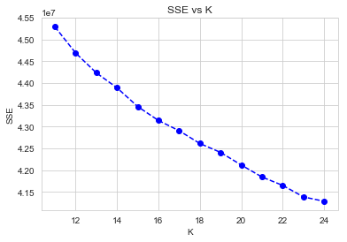

```python
# Investigate the change in within-cluster distance across number of clusters.
# HINT: Use matplotlib's plot function to visualize this relationship.
plt.plot(k_vals[10:], scores[10:], linestyle='--', marker='o', color='b')
plt.xlabel('K')
plt.ylabel('SSE')
plt.title('SSE vs K')
```

```python
# Re-fit the k-means model with the selected number of clusters and obtain
# cluster predictions for the general population demographics data.
kmeans = KMeans(n_clusters=17)
kmeans_model = kmeans.fit(data_pca)
general_population_preds = kmeans_model.predict(data_pca)
```

### Step 3.2: Apply All Steps to the Customer Data

Now that you have clusters and cluster centers for the general population, it's time to see how the customer data maps on to those clusters. Take care to not confuse this for re-fitting all of the models to the customer data. Instead, you're going to use the fits from the general population to clean, transform, and cluster the customer data. In the last step of the project, you will interpret how the general population fits apply to the customer data.

- Don't forget when loading in the customers data, that it is semicolon (`;`) delimited.
- Apply the same feature wrangling, selection, and engineering steps to the customer demographics using the `clean_data()` function you created earlier. (You can assume that the customer demographics data has similar meaning behind missing data patterns as the general demographics data.)
- Use the sklearn objects from the general demographics data, and apply their transformations to the customers data. That is, you should not be using a `.fit()` or `.fit_transform()` method to re-fit the old objects, nor should you be creating new sklearn objects! Carry the data through the feature scaling, PCA, and clustering steps, obtaining cluster assignments for all of the data in the customer demographics data.

```python
# Load in the customer demographics data.
customer_data = pd.read_csv('Udacity_CUSTOMERS_Subset.csv', sep=';')
customer_data.describe()
```

|  | AGER_TYP | ALTERSKATEGORIE_GROB | ANREDE_KZ | CJT_GESAMTTYP | FINANZ_MINIMALIST | FINANZ_SPARER | FINANZ_VORSORGER | FINANZ_ANLEGER | FINANZ_UNAUFFAELLIGER | FINANZ_HAUSBAUER | ... | PLZ8_ANTG1 | PLZ8_ANTG2 | PLZ8_ANTG3 | PLZ8_ANTG4 | PLZ8_BAUMAX | PLZ8_HHZ | PLZ8_GBZ | ARBEIT | ORTSGR_KLS9 | RELAT_AB |
| --- | --- | --- | --- | --- | --- | --- | --- | --- | --- | --- | --- | --- | --- | --- | --- | --- | --- | --- | --- | --- | --- |
| count | 191652.000000 | 191652.000000 | 191652.000000 | 188439.000000 | 191652.000000 | 191652.000000 | 191652.000000 | 191652.000000 | 191652.000000 | 191652.000000 | ... | 138888.000000 | 138888.000000 | 138888.000000 | 138888.000000 | 138888.000000 | 138888.000000 | 138888.000000 | 141176.000000 | 141176.000000 | 141176.000000 |
| mean | 0.344359 | 3.060907 | 1.376432 | 3.677928 | 3.963773 | 2.057051 | 4.183317 | 2.439808 | 2.646176 | 2.781176 | ... | 2.537404 | 2.731510 | 1.388817 | 0.539939 | 1.556607 | 3.634893 | 3.622192 | 2.824850 | 5.119517 | 2.898510 |
| std | 1.391672 | 1.086254 | 0.484492 | 1.813975 | 1.036230 | 1.319422 | 0.995365 | 1.697932 | 1.586506 | 1.147353 | ... | 0.904927 | 0.840922 | 0.885038 | 0.637048 | 1.185736 | 0.933660 | 1.008472 | 1.012415 | 2.159184 | 1.422683 |
| min | -1.000000 | 1.000000 | 1.000000 | 1.000000 | 1.000000 | 1.000000 | 1.000000 | 1.000000 | 1.000000 | 1.000000 | ... | 0.000000 | 0.000000 | 0.000000 | 0.000000 | 1.000000 | 1.000000 | 1.000000 | 1.000000 | 1.000000 | 1.000000 |
| 25% | -1.000000 | 3.000000 | 1.000000 | 2.000000 | 3.000000 | 1.000000 | 3.000000 | 1.000000 | 1.000000 | 2.000000 | ... | 2.000000 | 2.000000 | 1.000000 | 0.000000 | 1.000000 | 3.000000 | 3.000000 | 2.000000 | 4.000000 | 2.000000 |
| 50% | 0.000000 | 3.000000 | 1.000000 | 4.000000 | 4.000000 | 1.000000 | 5.000000 | 2.000000 | 2.000000 | 3.000000 | ... | 3.000000 | 3.000000 | 1.000000 | 0.000000 | 1.000000 | 3.000000 | 4.000000 | 3.000000 | 5.000000 | 3.000000 |
| 75% | 2.000000 | 4.000000 | 2.000000 | 6.000000 | 5.000000 | 4.000000 | 5.000000 | 5.000000 | 5.000000 | 3.000000 | ... | 3.000000 | 3.000000 | 2.000000 | 1.000000 | 1.000000 | 4.000000 | 4.000000 | 4.000000 | 7.000000 | 4.000000 |
| max | 3.000000 | 9.000000 | 2.000000 | 6.000000 | 5.000000 | 5.000000 | 5.000000 | 5.000000 | 5.000000 | 5.000000 | ... | 4.000000 | 4.000000 | 3.000000 | 2.000000 | 5.000000 | 5.000000 | 5.000000 | 9.000000 | 9.000000 | 9.000000 |

8 rows × 81 columns

```python
# Clean the customers data
cleaned_customer_data = clean_data(customer_data)
cleaned_customer_data.describe()
```

|  | ALTERSKATEGORIE_GROB | ANREDE_KZ | FINANZ_MINIMALIST | FINANZ_SPARER | FINANZ_VORSORGER | FINANZ_ANLEGER | FINANZ_UNAUFFAELLIGER | FINANZ_HAUSBAUER | GREEN_AVANTGARDE | HEALTH_TYP | ... | ZABEOTYP_1 | ZABEOTYP_2 | ZABEOTYP_3 | ZABEOTYP_4 | ZABEOTYP_5 | ZABEOTYP_6 | PRAEGENDE_JUGENDJAHRE_MOVEMENT | PRAEGENDE_JUGENDJAHRE_DECADE | CAMEO_INTL_2015_WEALTH | CAMEO_INTL_2015_LIFE_STAGE |
| --- | --- | --- | --- | --- | --- | --- | --- | --- | --- | --- | --- | --- | --- | --- | --- | --- | --- | --- | --- | --- | --- |
| count | 120008.000000 | 120042.000000 | 120042.000000 | 120042.000000 | 120042.000000 | 120042.000000 | 120042.000000 | 120042.000000 | 120042.000000 | 119843.000000 | ... | 120042.000000 | 120042.000000 | 120042.000000 | 120042.000000 | 120042.000000 | 120042.000000 | 119947.000000 | 119947.00000 | 119971.000000 | 119971.000000 |
| mean | 3.519824 | 1.321496 | 4.297621 | 1.399069 | 4.590677 | 1.572550 | 1.800453 | 2.740924 | 0.525266 | 1.977312 | ... | 0.399110 | 0.046759 | 0.408016 | 0.106871 | 0.006214 | 0.033030 | 0.525682 | 58.57412 | 2.569438 | 3.391111 |
| std | 0.683993 | 0.467053 | 0.997126 | 0.798266 | 0.822090 | 0.975208 | 0.932775 | 1.294907 | 0.499363 | 0.771532 | ... | 0.489718 | 0.211122 | 0.491468 | 0.308950 | 0.078587 | 0.178716 | 0.499342 | 13.25793 | 1.402460 | 1.332140 |
| min | 1.000000 | 1.000000 | 1.000000 | 1.000000 | 1.000000 | 1.000000 | 1.000000 | 1.000000 | 0.000000 | 1.000000 | ... | 0.000000 | 0.000000 | 0.000000 | 0.000000 | 0.000000 | 0.000000 | 0.000000 | 40.00000 | 1.000000 | 1.000000 |
| 25% | 3.000000 | 1.000000 | 4.000000 | 1.000000 | 4.000000 | 1.000000 | 1.000000 | 2.000000 | 0.000000 | 1.000000 | ... | 0.000000 | 0.000000 | 0.000000 | 0.000000 | 0.000000 | 0.000000 | 0.000000 | 50.00000 | 1.000000 | 2.000000 |
| 50% | 4.000000 | 1.000000 | 5.000000 | 1.000000 | 5.000000 | 1.000000 | 2.000000 | 2.000000 | 1.000000 | 2.000000 | ... | 0.000000 | 0.000000 | 0.000000 | 0.000000 | 0.000000 | 0.000000 | 1.000000 | 60.00000 | 2.000000 | 4.000000 |
| 75% | 4.000000 | 2.000000 | 5.000000 | 2.000000 | 5.000000 | 2.000000 | 2.000000 | 4.000000 | 1.000000 | 3.000000 | ... | 1.000000 | 0.000000 | 1.000000 | 0.000000 | 0.000000 | 0.000000 | 1.000000 | 70.00000 | 4.000000 | 4.000000 |
| max | 4.000000 | 2.000000 | 5.000000 | 5.000000 | 5.000000 | 5.000000 | 5.000000 | 5.000000 | 1.000000 | 3.000000 | ... | 1.000000 | 1.000000 | 1.000000 | 1.000000 | 1.000000 | 1.000000 | 1.000000 | 90.00000 | 5.000000 | 5.000000 |

8 rows × 95 columns

```python
print(final_data.shape)
print(cleaned_customer_data.shape)
```

```
(722258, 95)
(120042, 95)
```

```python
# Apply preprocessing, feature transformation, and clustering from the general
# demographics onto the customer data, obtaining cluster predictions for the
# customer demographics data.
imputed_customer_data = imp_mean.transform(cleaned_customer_data)
scaled_customer_data = scaler.transform(imputed_customer_data)
pca_customer_data = pca.transform(scaled_customer_data)
customers_preds = kmeans_model.predict(pca_customer_data)
```

### Step 3.3: Compare Customer Data to Demographics Data

At this point, you have clustered data based on demographics of the general population of Germany, and seen how the customer data for a mail-order sales company maps onto those demographic clusters. In this final substep, you will compare the two cluster distributions to see where the strongest customer base for the company is.

Consider the proportion of persons in each cluster for the general population, and the proportions for the customers. If we think the company's customer base to be universal, then the cluster assignment proportions should be fairly similar between the two. If there are only particular segments of the population that are interested in the company's products, then we should see a mismatch from one to the other. If there is a higher proportion of persons in a cluster for the customer data compared to the general population (e.g. 5% of persons are assigned to a cluster for the general population, but 15% of the customer data is closest to that cluster's centroid) then that suggests the people in that cluster to be a target audience for the company. On the other hand, the proportion of the data in a cluster being larger in the general population than the customer data (e.g. only 2% of customers closest to a population centroid that captures 6% of the data) suggests that group of persons to be outside of the target demographics.

Take a look at the following points in this step:

- Compute the proportion of data points in each cluster for the general population and the customer data. Visualizations will be useful here: both for the individual dataset proportions, but also to visualize the ratios in cluster representation between groups. Seaborn's [`countplot()`](https://seaborn.pydata.org/generated/seaborn.countplot.html) or [`barplot()`](https://seaborn.pydata.org/generated/seaborn.barplot.html) function could be handy.
  - Recall the analysis you performed in step 1.1.3 of the project, where you separated out certain data points from the dataset if they had more than a specified threshold of missing values. If you found that this group was qualitatively different from the main bulk of the data, you should treat this as an additional data cluster in this analysis. Make sure that you account for the number of data points in this subset, for both the general population and customer datasets, when making your computations!
- Which cluster or clusters are overrepresented in the customer dataset compared to the general population? Select at least one such cluster and infer what kind of people might be represented by that cluster. Use the principal component interpretations from step 2.3 or look at additional components to help you make this inference. Alternatively, you can use the `.inverse_transform()` method of the PCA and StandardScaler objects to transform centroids back to the original data space and interpret the retrieved values directly.
- Perform a similar investigation for the underrepresented clusters. Which cluster or clusters are underrepresented in the customer dataset compared to the general population, and what kinds of people are typified by these clusters?

```python
# Compare the proportion of data in each cluster for the customer data to the
# proportion of data in each cluster for the general population.
print('General population count per cluster')
df_gp_preds_count = pd.DataFrame.from_dict(Counter(general_population_preds), orient='index').reset_index().rename(columns={'index':'cluster', 0:'count'})
df_gp_preds_count['% of values'] = round(df_gp_preds_count['count'] / len(general_population_preds), 4) * 100
print(df_gp_preds_count)
print('\n')
print('Customers count per cluster')
df_customers_preds_count = pd.DataFrame.from_dict(Counter(customers_preds), orient='index').reset_index().rename(columns={'index':'cluster', 0:'count'})
df_customers_preds_count['% of values'] = round(df_customers_preds_count['count'] / len(customers_preds), 4) * 100
print(df_customers_preds_count)
```

```
General population count per cluster
    cluster  count  % of values
0         0  54756         7.58
1         1  38254         5.30
2         2  45607         6.31
3         3  58671         8.12
4         4  41910         5.80
5         5  45794         6.34
6         6  49903         6.91
7         7  25326         3.51
8         8  56021         7.76
9         9  21233         2.94
10       10  41596         5.76
11       11  52734         7.30
12       12  42553         5.89
```

[output cut: 25 more lines]

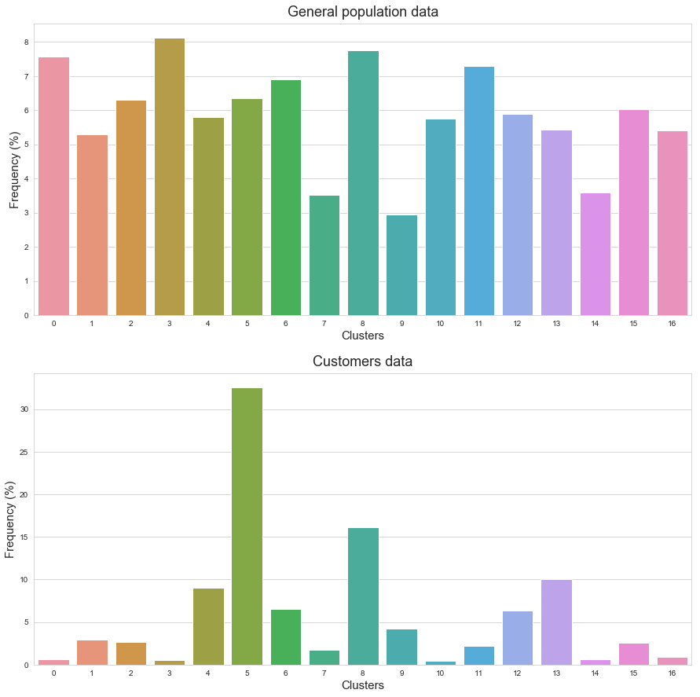

```python
fig, axes = plt.subplots(nrows=2, ncols=1, figsize=(15, 15))
axes[0].set_title("General population data", fontsize=18)
gp_plt = sns.barplot(x='cluster', y='% of values', data=df_gp_preds_count, ax=axes[0])
sns.set_style('whitegrid')
gp_plt.set_ylabel("Frequency (%)",fontsize=15)
gp_plt.set_xlabel("Clusters",fontsize=15)
axes[1].set_title("Customers data", fontsize=18)
customers_plt = sns.barplot(x='cluster', y='% of values', data=df_customers_preds_count, ax=axes[1])
customers_plt.set_ylabel("Frequency (%)",fontsize=15)
customers_plt.set_xlabel("Clusters",fontsize=15)
```

```python
# What kinds of people are part of a cluster that is overrepresented in the
# customer data compared to the general population?

cleaned_customer_data['Cluster prediction'] = customers_preds
final_data['Cluster prediction'] = general_population_preds
```

```python
def compare(cluster, col):
    customers = cleaned_customer_data[cleaned_customers_data['Cluster prediction'] == cluster][col]
    customers_count = pd.DataFrame.from_dict(Counter(customers), orient='index').reset_index().rename(columns={'index':'values', 0:'count'})
    customers_count['% of values'] = round(customers_count['count'] / len(customers), 4) * 100


    gp = final_data[final_data['Cluster prediction'] == cluster][col]
    gp_count = pd.DataFrame.from_dict(Counter(gp), orient='index').reset_index().rename(columns={'index':'values', 0:'count'})
    gp_count['% of values'] = round(gp_count['count'] / len(gp), 4) * 100


    fig, axes = plt.subplots(1, 2)
    plt.tight_layout(w_pad=5.0)
    axes[0].set_title("General population", fontsize=15)
    axes[1].set_title("Customers", fontsize=15)

    sns_plt = sns.barplot(x='values', y='% of values', data=customers_count, ax=axes[0])
    sns_plt.set_ylabel("Frequency (%)", fontsize=12)
    sns_plt.set_xlabel("Values", fontsize=12)


    sns_plt = sns.barplot(x='values', y='% of values', data=gp_count, ax=axes[1])
    sns_plt.set_ylabel("Frequency (%)", fontsize=12)
    sns_plt.set_xlabel("Values", fontsize=12)
```

The values and meanings for FINANZ_SPARER (money-saver) and FINANZ_MINIMALIST (low financial interest) are :

- 1: very high
- 2: high
- 3: average
- 4: low
- 5: very low

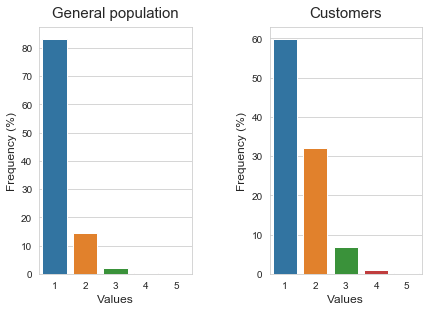

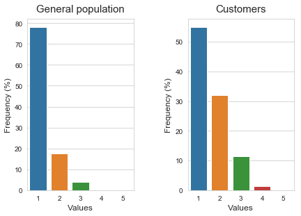

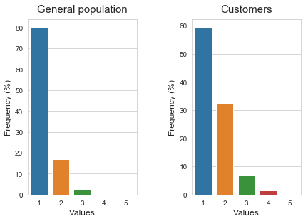

```python
# Compare for FINANZ_SPARER

# Customers belonging to cluster #5
compare(5, 'FINANZ_SPARER')

# Customers belonging to cluster #8
compare(8, 'FINANZ_SPARER')

# Customers belonging to cluster #13
compare(13, 'FINANZ_SPARER')
```

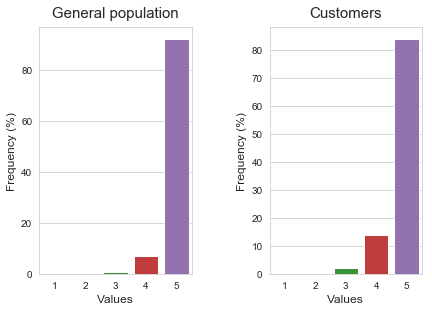

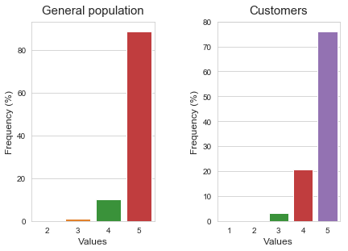

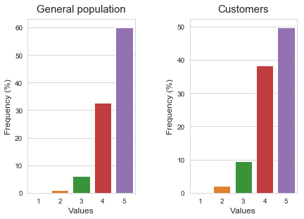

```python
# Compare for FINANZ_MINIMALIST

compare(5, 'FINANZ_MINIMALIST')

compare(8, 'FINANZ_MINIMALIST')

compare(13, 'FINANZ_MINIMALIST')
```

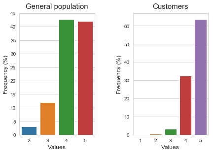

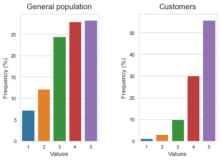

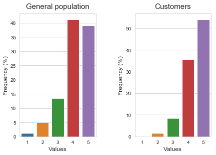

```python
# What kinds of people are part of a cluster that is underrepresented in the
# customer data compared to the general population?

# Customers belonging to cluster #0
compare(0, 'FINANZ_SPARER')

# Customers belonging to cluster #3
compare(3, 'FINANZ_SPARER')

# Customers belonging to cluster #10
compare(10, 'FINANZ_SPARER')
```

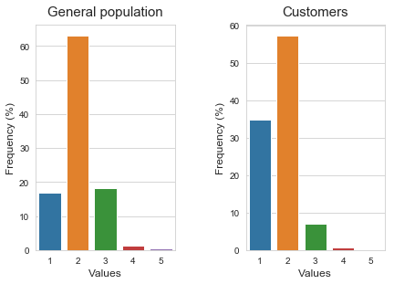

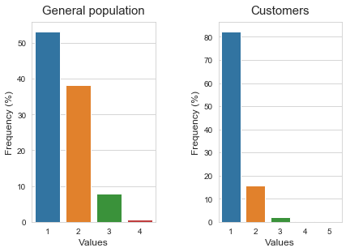

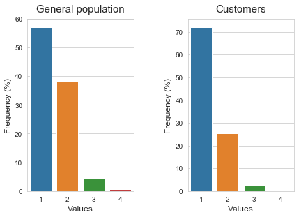

```python
# Customers belonging to cluster #0
compare(0, 'FINANZ_MINIMALIST')

# Customers belonging to cluster #3
compare(3, 'FINANZ_MINIMALIST')

# Customers belonging to cluster #10
compare(10, 'FINANZ_MINIMALIST')
```

### Discussion 3.3: Compare Customer Data to Demographics Data

```python
def compare_all(cluster_over, cluster_under, col):
    """Make an overall comparison between the general population, the clustered general population,
       the overrepresented customers clustering, and the underrepresented customers clustering."""

    overall_general_population = final_data[col]
    overall_general_population_count = pd.DataFrame.from_dict(Counter(overall_general_population), orient='index').reset_index().rename(columns={'index':'values', 0:'count'})
    overall_general_population_count['% of values'] = round(overall_general_population_count['count'] / len(overall_general_population), 4) * 100


    gp = final_data[final_data['Cluster prediction'] == cluster_over][col]
    gp_count = pd.DataFrame.from_dict(Counter(gp), orient='index').reset_index().rename(columns={'index':'values', 0:'count'})
    gp_count['% of values'] = round(gp_count['count'] / len(gp), 4) * 100


    customers = cleaned_customer_data[cleaned_customers_data['Cluster prediction'] == cluster_over][col]
    customers_count = pd.DataFrame.from_dict(Counter(customers), orient='index').reset_index().rename(columns={'index':'values', 0:'count'})
    customers_count['% of values'] = round(customers_count['count'] / len(customers), 4) * 100


    under_customers = cleaned_customer_data[cleaned_customers_data['Cluster prediction'] == cluster_under][col]
    under_customers_count = pd.DataFrame.from_dict(Counter(under_customers), orient='index').reset_index().rename(columns={'index':'values', 0:'count'})
    under_customers_count['% of values'] = round(under_customers_count['count'] / len(under_customers), 4) * 100


    fig, axes = plt.subplots(nrows=4, ncols=1, figsize=(10, 10))
    plt.tight_layout(h_pad=5.0)
    axes[0].set_title("Overall general population", fontsize=15)
    axes[1].set_title("General population in cluster", fontsize=15)
    axes[2].set_title("Customers overrepresented by cluster", fontsize=15)
    axes[3].set_title("Customers underepresented by cluster", fontsize=15)

    sns_plt = sns.barplot(x='values', y='% of values', data=overall_general_population_count, ax=axes[0])
    sns_plt.set_ylabel("Frequency (%)", fontsize=12)
    sns_plt.set_xlabel("Values", fontsize=12)

    sns_plt = sns.barplot(x='values', y='% of values', data=gp_count, ax=axes[1])
    sns_plt.set_ylabel("Frequency (%)", fontsize=12)
    sns_plt.set_xlabel("Values", fontsize=12)

    sns_plt = sns.barplot(x='values', y='% of values', data=customers_count, ax=axes[2])
    sns_plt.set_ylabel("Frequency (%)", fontsize=12)
    sns_plt.set_xlabel("Values", fontsize=12)


    sns_plt = sns.barplot(x='values', y='% of values', data=under_customers_count, ax=axes[3])
    sns_plt.set_ylabel("Frequency (%)", fontsize=12)
    sns_plt.set_xlabel("Values", fontsize=12)
```

Another important attribute from the PCA analysis made above is 'HH_EINKOMMEN_SCORE' (Estimated household net income). Lets' analyse it. The values for that attribute are

- 1: highest income
- 2: very high income
- 3: high income
- 4: average income
- 5: lower income
- 6: very low income

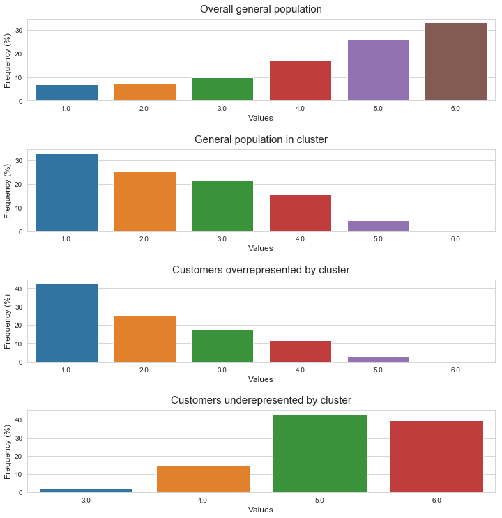

```python
compare_all(5, 0, 'HH_EINKOMMEN_SCORE')
```

As we can see, the people with the highest income and very high income are target audience for the company, and in opposite, people with low income are not. That makes sense, since the people with high income are more likely to purcharse from the company, and are also more likely to be recurrent buyers.

Another interesting attribute is 'EWDICHTE' (Density of households per square kilometer). The values are :

- 1: less than 34 households per km^2
- 2: 34 - 89 households per km^2
- 3: 90 - 149 households per km^2
- 4: 150 - 319 households per km^2
- 5: 320 - 999 households per km^2
- 6: more than 999 households per km^2

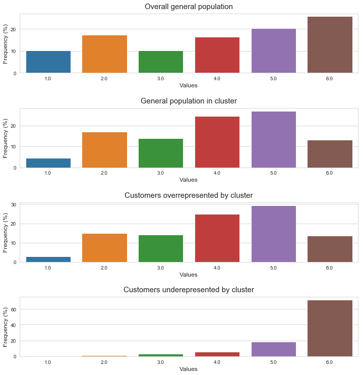

```python
compare_all(5, 0, 'EWDICHTE')
```

We can see that customers tend to be in dense, but not in very dense cities. Normally, dense cities are near the cities that are very dense, and the people living in there are more in need of services from a mail-order company.

Finally, another important attribute is 'ORTSGR_KLS9' (Size of community), that hav the following values :

- 1: <= 2,000 inhabitants
- 2: 2,001 to 5,000 inhabitants
- 3: 5,001 to 10,000 inhabitants
- 4: 10,001 to 20,000 inhabitants
- 5: 20,001 to 50,000 inhabitants
- 6: 50,001 to 100,000 inhabitants
- 7: 100,001 to 300,000 inhabitants
- 8: 300,001 to 700,000 inhabitants
- 9: > 700,000 inhabitants

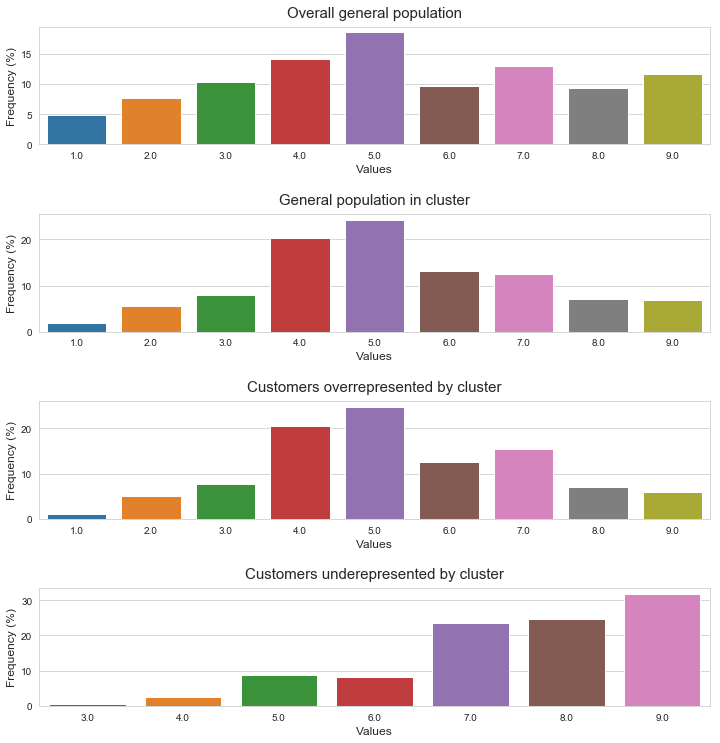

```python
compare_all(5, 0, 'ORTSGR_KLS9')
```

The customers living in a medium size community are the most likely to be customers of the company services. That goes in pair with the conclusion that we made above that people living in medium large communities with medium density are the most likely to require services from a mail-order company.

> Congratulations on making it this far in the project! Before you finish, make sure to check through the entire notebook from top to bottom to make sure that your analysis follows a logical flow and all of your findings are documented in **Discussion** cells. Once you've checked over all of your work, you should export the notebook as an HTML document to submit for evaluation. You can do this from the menu, navigating to **File -> Download as -> HTML (.html)**. You will submit both that document and this notebook for your project submission.